# Improved churn prediction in telecommunication industry using data mining techniques - ScienceDirect

## Outline

1. Highlights
2. Abstract
3. Graphical abstract
4. Keywords
5. 1. Motivation and significance
6. 2. Introduction
7. 3. Literature review
8. 4. Data mining techniques
9. 5. Experiments
10. 6. Proposed methodology
11. 7. Conclusion and future research
12. Appendix A.
13. Appendix B.
14. References

## Figures (6)

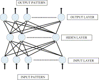

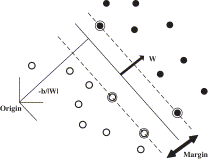

## Tables (28)

1. Table 1
2. Table 2
3. Table 3
4. Table 4
5. Table 5
6. Table 6

## [Applied Soft Computing](https://www.sciencedirect.com/science/journal/15684946)

[Volume 24](https://www.sciencedirect.com/science/journal/15684946/24/supp/C), November 2014, Pages 994-1012

# Improved churn prediction in telecommunication industry using data mining techniques

[A.Keramati<sup>a</sup>](https://www.sciencedirect.com/science/article/pii/S1568494614004062?via%3Dihub#!)[R.Jafari-Marandi<sup>a</sup>](https://www.sciencedirect.com/science/article/pii/S1568494614004062?via%3Dihub#!)[M.Aliannejadi<sup>b</sup>](https://www.sciencedirect.com/science/article/pii/S1568494614004062?via%3Dihub#!)[I.Ahmadian<sup>c</sup>](https://www.sciencedirect.com/science/article/pii/S1568494614004062?via%3Dihub#!)[M.Mozaffari<sup>a</sup>](https://www.sciencedirect.com/science/article/pii/S1568494614004062?via%3Dihub#!)[U.Abbasi<sup>a</sup><sup>d</sup>](https://www.sciencedirect.com/science/article/pii/S1568494614004062?via%3Dihub#!)

https://doi.org/10.1016/j.asoc.2014.08.041[Get rights and content](https://s100.copyright.com/AppDispatchServlet?publisherName=ELS&contentID=S1568494614004062&orderBeanReset=true)

## Highlights

**•**

We have employed [Decision Tree](https://www.sciencedirect.com/topics/computer-science/decision-trees), [Artificial Neural Networks](https://www.sciencedirect.com/topics/computer-science/artificial-neural-network), K-Nearest Neighbors, and [Support Vector Machine](https://www.sciencedirect.com/topics/computer-science/support-vector-machine) to improve churn prediction.

**•**

Using the data of an Iranian mobile company these techniques were experienced and were compared to each other.

**•**

We proposed a hybrid methodology which made considerable improvements to the value of some of [evaluations metrics](https://www.sciencedirect.com/topics/computer-science/evaluation-metric).

**•**

Results showed that above 95% accuracy for Recall and Precision is easily achievable.

**•**

A new methodology for extracting influential features is introduced and experienced.

## Abstract

To survive in today's telecommunication business it is imperative to distinguish customers who are not reluctant to move toward a competitor. Therefore, customer churn prediction has become an essential issue in telecommunication business. In such competitive business a reliable customer predictor will be regarded priceless. This paper has employed data mining classification techniques including Decision Tree, Artificial Neural Networks, K-Nearest Neighbors, and Support Vector Machine so as to compare their performances. Using the data of an Iranian mobile company, not only were these techniques experienced and compared to one another, but also we have drawn a parallel between some different prominent data mining software. Analyzing the techniques’ behavior and coming to know their specialties, we proposed a hybrid methodology which made considerable improvements to the value of some of the evaluations metrics. The proposed methodology results showed that above 95% accuracy for Recall and Precision is easily achievable. Apart from that a new methodology for extracting influential features in dataset was introduced and experienced.

## Graphical abstract

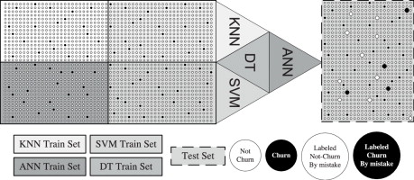

## Keywords

Telecommunication

Churn prediction

ANN

KNN

SVM

Decision tree

## 1. Motivation and significance

Nowadays business managers have started to appreciate the important role of churn prediction in their way of prosperity. In the literature, it has been repeatedly indicated that customer retention in comparison to absorbing new customers is significantly more achievable and less expensive. In today's competitive business environment, losing a customer should be considered as a real disaster. Loss of a customer can be contemplated in three different aspects. First, losing existing customers is figuratively equivalent to have a critical machine irreparably broken down due to the fact that they are any company's most precious assets. Furthermore, by the same imaginary assumption, losing a customer would mean passing our asset intentionally to our competitor. Finally it is too laborious a task to gain a new customer. To make the matters worse, even if a new customer were absorbed, they even would not be as loyal as the old customers. It may take some time for just a proportion of them to become slightly loyal. Therefore, the prevention strategy is absolutely worthwhile. Customer retention plays a major role in many enterprises, especially matured ones, including [telecommunications](https://www.sciencedirect.com/topics/engineering/telecommunication) and finances [1]. Acquiring it requires and rears churn prediction, which is another term and keyword in customer retention. It can be explained as predicting customers’ probable tendency to switch to our competitor.

In today's telecommunication business environment, competition is tremendously fierce. The services and customers’ options also have become more comparable and more competitive. This is the reason why customer loyalty tends to erode. It costs customers figuratively nothing to switch from a service provider to another. They are customers after all and they have freewill to switch to a better and probably more inexpensive service in a competitive market. We, as company managers, ought to take every necessary step so as to get in their way of leaving. It is imperative to distinguish customers who are not reluctant to move toward another competitor before they actually consider so. Therefore, dealing with the probability of customers’ churn has become an inevitable issue in telecommunication industry [2]. The telecommunication service companies are annually facing with loss of valuable customers to competitors. Due to the changes and improvements in telecommunications’ services technologies in the last few years, customers’ churn has resulted in magnificent losses and it has proven itself as a real issue [3].

## 2. Introduction

The number of mobile phone users during past years has perceptibly multiplied. Statistical report for the end of 2010 indicated that the number of mobile phone users in Iran has surpassed 70 million, more than 90% of the country population. Therefore, telecommunication market is in the point of being saturated, especially for big cities. Mobile phone penetration rates for certain city have gone above 100%, which means there are more subscriptions than inhabitants. As a result, heat of the competition in today's telecommunication market is distinguishably high. Proposed products and service offerings are becoming more and more similar and replaceable. The fact that customers, in most of the cases, are able to self-centrically prefer a service provider better brings about the eroding of customer loyalty. Then, Iran telecom operators in near future need to start giving a great amount of attention to customer churn prediction and customer retention strategies and should they fail to do so they would not survive. Furthermore, it has been repeatedly shown that taking customer retention strategy can be profitable for a company [4].

Not so long ago [data mining techniques](https://www.sciencedirect.com/topics/computer-science/data-mining-techniques) have been in use to tackle the challenging customer churn problems in telecommunication service field [3]. Due to the aforementioned heat of the competition in telecommunication market, these [data mining](https://www.sciencedirect.com/topics/computer-science/data-mining) techniques are mainly employed to cope with the churn prediction issues which has been receiving an unprecedented attention in the telecommunication industry and research. They are mostly and prevalently applied using the customer log-files or questionnaires so as to come up with some knowledge helping to determine the customers who are likely to churn. Although most of these data mining techniques use essentially different techniques to achieve approximately same result, the knowledge is totally worth spending and beneficial for almost any telecommunication company. The following paragraph is devoted to illustrate the importance of exact churn prediction.

Applying data mining techniques itself can be time-consuming and extravagantly expensive. Data Gathering, Data Cleaning, and [Data Preprocessing](https://www.sciencedirect.com/topics/computer-science/data-preprocessing) in Iran rather immature telecommunication companies also can be painstakingly hard. It is important to understand that the knowledge extracted for data mining probably will be employed to make important decisions about the customers who are repeatedly known as the most important asset of any business. Therefore, the more accurate and reliable the extracted knowledge is, the more proper and appropriate decisions can be made. Making appropriate decision about such a vulnerable matter needs tremendous certainty and that is achievable by reliable knowledge extracted by reliable techniques. On the other hand, improper decision based on falsified, bias or flawed knowledge may lead to devastating situations where no one can make restitution.

Contemplating previous researches, they can be categorized by two main aspects. First is the studies which were centrally concerned about churn determinants. They analyzed well-known churn determinates and verified them by using customer behaviors in telecommunication. Some attributes, such as customer satisfaction, switching costs, customer demographics, tendency to [change behavior](https://www.sciencedirect.com/topics/engineering/behaviour-change), and service usage, have been prevalent among churn determinants [1]. Second, there are other studies such as this paper whose authors’ interest has been to improve the outcome of churn prediction by state of the art computational methods. Having said that, although this paper's main part is to propose a novel methodology for more accurate prediction, a feature extraction method for [dimensionality reduction](https://www.sciencedirect.com/topics/computer-science/dimensionality-reduction) is also presented.

A rather distinguished and important part of this paper is the idea of using intelligent algorithms for prediction of future matters. Intelligent algorithm has proven to be versatile and applicable for different tasks. They have been in use in variety of problems, the subject matter be Internet such as [5], [6], [ATM](https://www.sciencedirect.com/topics/engineering/automatic-teller-machines) management [7], or the most basic statistical problem estimating missing value [8]. There have been many research works which employ neuro-fuzzy inference system to combine the advantages of fuzzy logic and [neural network](https://www.sciencedirect.com/topics/computer-science/neural-networks) for classification and [regression problems](https://www.sciencedirect.com/topics/computer-science/regression-problem). There are many articles as an example for this adaptation: [9], [10], [11], [12], [13], [14]. The combination of neural network and fuzzy logic in these studies benefits mostly from the human-like logic behind fuzzy systems and the connections of the neural networks. There are, moreover, approaches in which the use of [meta-heuristic algorithms](https://www.sciencedirect.com/topics/computer-science/metaheuristic-algorithm) such as [Genetic Algorithm](https://www.sciencedirect.com/topics/engineering/genetic-algorithm) (GA) for the [parameter estimation](https://www.sciencedirect.com/topics/engineering/parameter-estimation) of neural network or fuzzy system had been employed: [15], [16]. Taking this strategy has many advantages because these types of problems are not closed form and more than too often the researcher opts to use an iterative algorithm to estimate their parameters. Meta-heuristic algorithms converge at a local minimum/maximum which is proven to be often sufficient. All the aforementioned works try to utilize intelligent algorithm to improve their estimates. These estimates in many works have come to natural phenomena. Such approaches have made great advances in different discipline such as production and inventory, or even natural hazards and risk management: [17], [18], [19], [20], [21], [22].

However this paper's most important contribution is the churn prediction improvement by hybridizing some well-known algorithm. After experimenting with four mentioned prominent algorithms and coming to know their special features, a hybrid algorithm using all four is introduced. Not only did we prove that the suggested methodology is competitive with the best of the four, but also it has a tuning parameter that can be manipulated to predict the way its users need. If a decision maker needs to exactly know which customers will be churned, or if they want to realize who are the customers that have even slightest tendency to leave, the algorithm can be tuned to return the desired outcomes. Computational achievement in this paper is really strong since it has been able to push recall and precision measures, two of the most important measures for evaluating binary prediction, not to return less than 95% accuracy. Moreover, as it is an essential part of any [data mining task](https://www.sciencedirect.com/topics/computer-science/data-mining-task) we have investigated into the influence of the columns in our data. In real world setting computational limitation can bring about many restrictions. Thus, knowing the most influential columns can save many times an effort. To that end, a novel feature extraction methodology is suggested. The suggested method is experienced and consequently compared to traditional statistical means.

The rest of this paper is organized by 5 other sections. Section 3 is a short review of other research papers concerning telecommunication churn prediction. Section 4 describes in details the four classifiers algorithm used in our experiments. Section 5 is to show our experiences and results, whereas in Section 6 a hybridized methodology is explained and illustrated. Last but not least, Section 7 is the final discussion and conclusion of this paper experiments.

## 3. Literature review

Accurate and reliable prediction of churn customer is important in the development of appropriate retention strategies. Huang et al. [3] proposed a method based on ordinal regression to predict time of churn and tenure of customer in mobile telecommunication industry. They treated customer tenure as an ordinal outcome variable and take advantage of ordinal regression to form a model. Their results showed that ordinal regression could be an alternative technique for survival analysis for the prediction of mobile customers’ churn time. This paper has been the first study, its authors claimed, to use ordinal regression as a potential technique for modeling customer tenure. Zhang et al. [1] investigated the effects of interpersonal influence on the accuracy of customer churn predictions and proposed a novel prediction model that is based on interpersonal influence and combines the propagation process and customers’ personalized characters. The comparison between results of traditional attributes-based models, network attributes-based models and combined attributes models proved that incorporating network attributes into predicting models can greatly improve prediction accuracy. Kim et al. [23] examined the communication patterns among subscribers in a mobile telecommunication company and introduced [network analysis](https://www.sciencedirect.com/topics/engineering/electric-network-analysis). They accomplished further improvements in churn prediction compared with the traditional [machine learning approach](https://www.sciencedirect.com/topics/computer-science/machine-learning-approach) that handles personal information stored in companies considering a propagation process in a network based on [call detail records](https://www.sciencedirect.com/topics/computer-science/call-detail-record) which transfers churning information from churners to non-churners. In a rather novel study, Verbeke et al. [24] used social network information to predict churn. They present an alternative modeling approach that integrates social network effects within a customer churn prediction setting using relational [learning algorithm](https://www.sciencedirect.com/topics/computer-science/learning-algorithm). Non-Markovian network effects are incorporated within relational classifiers. In this study, significant impact of social network effects on the performance of a customer churn prediction model is discussed and a novel parallel modeling setup is introduced to boost the profits generated by a retention campaign.

Hung et al. [25] intended to illustrate how to apply IT technology in order to facilitate telecom churn management. Their main goal, unlike to the most of other churn analysis research, was not to predict customer's churning attitude so as to decide what measures should be taken about the retention. However, authors opted for [decision tree](https://www.sciencedirect.com/topics/computer-science/decision-trees), [neural network](https://www.sciencedirect.com/topics/computer-science/neural-networks) and K-means cluster among [data mining techniques](https://www.sciencedirect.com/topics/computer-science/data-mining-techniques) to come up with a churn [predictive model](https://www.sciencedirect.com/topics/computer-science/predictive-model). They had categorized their churn attributes into three segments according to their billing amount (to assess ‘customer value’), tenure month (to appraise ‘customer loyalty’), and payment behaviors (to engage ‘customer credit risks’). Normally in churn analysis research the effective churn deterministic variables are chosen by running a regression model or other means; however, they simply used expertise's outlook in order to discern effective churn deterministic variables.

The purpose of using [association rules](https://www.sciencedirect.com/topics/computer-science/association-rules) is to reduce a large amount of information to a small and more understandable set of statistically supported statements [26]. Few studies have considered or illustrated the [pre-processing step](https://www.sciencedirect.com/topics/computer-science/preprocessing-step) during [data mining](https://www.sciencedirect.com/topics/computer-science/data-mining) whose aim is to filter out unrepresentative data or information. All the same, the aim of Tsai and Chen [27] was to examine whether association rules can be adapted in the data [pre-processing stage](https://www.sciencedirect.com/topics/computer-science/preprocessing-stage) to reduce a large amount of information to a small and more understandable data variables in order to improve the prediction performance of neural networks and decision trees. They, after discussing some preprocessing steps, presented the important processes of developing MOD customer churn prediction models by data mining techniques. Their study contains a pre-processing stage for selecting important variables by association rules and also it consisted of a model construction stage by neural networks (NN) and decision trees (DT). Their experimental results showed that using association rules allows the DT and NN models to provide better prediction performances over a chosen validated dataset. Authors also investigated the combination of the data reduction and model development steps using data mining techniques for the problem of MOD customer churn prediction.

Lee et al. [28] focused on building an accurate and concise predictive model with the purpose of churn prediction by utilizing a partial least squares (PLS)-based methodology on highly [correlated data](https://www.sciencedirect.com/topics/computer-science/correlated-data) sets among variables. Not only did they present a prediction model to accurately predict customers’ churning behavior but also a simple but implementable churn marketing program was employed. Their proposed methodology allows a marketing manager to maintain an optimal (at least a near optimal) level of churners effectively and efficiently through their marketing programs. In this research PLS is employed as the prediction modeling method. Ning et al. [29] conducted an experimental investigation of customer churn prediction in telecom industry and proposed the use of boosting to enhance a customer churn prediction model. Unlike other boosting methods that improve the accuracy of a given basis learner, the authors suggested to separate customers into two clusters based on the weight assigned by the boosting algorithm. The proposed model provides an opportunity to an “Implementation Zone” where customers with the highest churn propensity can be addressed for retention actions.

De Bock and Poel [30] evaluated rotation-based ensemble classifiers for the prediction of customer defection. In rotation-based ensembles, feature extraction algorithms are applied to rotate the training data that is presented for training member classifiers in the ensemble. They compared two ensemble-based ensemble algorithms, i.e., Rotation Forest and RotBoost, to a set of often used benchmark algorithms, in terms of accuracy, AUC and top-decile lift on four real-life customer churn prediction applications. Their other interesting contribution was that they compared the influence of the use of three alternative feature extraction algorithms, i.e., [principal component analysis](https://www.sciencedirect.com/topics/engineering/principal-component-analysis) (PCA), [independent component analysis](https://www.sciencedirect.com/topics/engineering/independent-component-analysis) (ICA) and sparse random projections (SRP) on classification performance of both RotBoost and Rotation Forest. Idris et al. [31] proposed an intelligent churn prediction system for telecom by employing ensemble [classification technique](https://www.sciencedirect.com/topics/computer-science/classification-technique). The performance evaluation conducted on standard telecom datasets shows the effectiveness of proposed approach, which is based on RotBoost in combination with [minimum redundancy](https://www.sciencedirect.com/topics/computer-science/minimum-redundancy) and maximum relevance features, in handling [high dimensionality](https://www.sciencedirect.com/topics/computer-science/high-dimensionality) of the telecom datasets and its high accuracy in predicting churners. In order to be able to better evaluate classification techniques, a cost-benefit analysis framework to the customer churn problem was applied by Verbraken et al. [32]. They proposed a new [performance measure](https://www.sciencedirect.com/topics/engineering/performance-measure-psi), the expected maximum profit criterion, which is aligned with the main objectives of the end users. Not only does the proposed framework assist companies with selecting the classifier which maximizes the profit, but also provides guidance about the fraction of the customer base to be included in the retention campaign.

Lin et al. [2] proposed three measurements including Modification Measures, Execution Effectiveness Measures and [Cost-Benefit Analysis](https://www.sciencedirect.com/topics/engineering/cost-benefit-analysis) to evaluate the effectiveness of the churn models after retaining potential churner. They showed to be appropriate effectiveness measures so as to assist in evaluation of execution effectiveness and give a proper feedback to adjust [data mining model](https://www.sciencedirect.com/topics/computer-science/data-mining-model) or redesign marketing activities. Authors also designed a real experimental architecture for telecom churn management application to use it as a pilot project for real adopting data mining model. Pendharkar [33] proposed two GA-based neural network (NN) models to predict customer churn in subscription of wireless services. Their first GA-based NN model uses a cross entropy based criterion to predict customer churn, and their second GA based NN model attempts to directly maximize the prediction accuracy of customer churn. Using real-world cellular wireless services dataset and three different sizes of NNs, they compared the two GA-based NN models with a statistical *z*-score model using several model evaluation criteria, which include prediction accuracy, top 10% docile lift and area under [receiver operating characteristics](https://www.sciencedirect.com/topics/engineering/receiver-operating-characteristic) (ROC) curve. The results of experiments indicate that both GA-based NN models outperform the statistical *z*-score model on all performance criteria.

Briefly, in other studies, Kim and Yoon [34] identified the determinants of subscriber churn and customer loyalty in the Korean mobile telephony market. Owczarczuk [35] tested the usefulness of the popular data mining models to predict the clients churn of the Polish cellular telecommunication company. Author dealt with prepaid clients who are far more likely to churn, less stable and much less we known about them. The results of his research showed that linear models, especially [logistic regression](https://www.sciencedirect.com/topics/computer-science/logistic-regression), are a very responsive choice to mode churn of the prepaid clients. Kisioglu and Topcu [36] constructed a model by [Bayesian Belief Network](https://www.sciencedirect.com/topics/computer-science/bayesian-belief-network) to identify the behaviors of customers propensity to churn. They analyzed three different scenarios that examine the characteristics of the churners and also suggested promotions to reduce the churn rate. Coussement and Van den Poel [37] developed a DSS for churn prediction. It tries to integrate free-formatted, textual information from customer emails with information derived from the marketing database. They investigated the beneficial effect of adding the voice of customers through call center emails – i.e. textual information – to a churn-prediction system that only uses traditional marketing information. Their findings proved having unstructured, textual information added into a conventional churn-prediction model will result in a significant increase in the prediction performance. Usero Sánchez and Asimakopoulos [38] examined the effects of mobile [number portability](https://www.sciencedirect.com/topics/computer-science/number-portability) (MNP) implementation on competition in the European Mobile communications industry. They concluded that subscriber churn rates are negatively affected by both the level of charges levied on subscribers wishing to maintain their current number (porting) when switching mobile providers and the length of time required switching. Sweeney and Swait [39] investigated the important additional role of the brand in managing the churn of current customers of relational services. Their research leaded to the enhanced understanding that the brand has a significant role to play in managing long-term customer relationships, and details how the usual tools of [customer relationship management](https://www.sciencedirect.com/topics/computer-science/customer-relationship-management), satisfaction and service quality, relate to brand credibility. Their results from samples of retail bank and long distance telephone company customers indicated that brand credibility serves a defensive role. Huang and Kechadi [40] proposed a hybrid model-based learning system, which integrates the supervised and [unsupervised techniques](https://www.sciencedirect.com/topics/computer-science/unsupervised-technique) for predicting customer behavior. The system combines a modified k-means [clustering algorithm](https://www.sciencedirect.com/topics/computer-science/clustering-algorithm) and a classic rule inductive technique (FOIL). Authors concluded that their hybrid model is very promising and outperform the existing models as the result of a comparative study on a set of benchmarks and use of real telecom datasets.

Contemplating Table 1, which is the summary for literature review, one can see that data mining techniques, such as Decision Tree, Neural Network, [Support vector machine](https://www.sciencedirect.com/topics/computer-science/support-vector-machine), Bayesian Belief Networks, and Regression, have been prevalently employed in telecommunication customer churn prediction studies. Nevertheless, just a few of them have gone through the process of tuning these techniques parameters in order to compare them to each other. In this paper we have experienced, tuned, and compared four prominent data mining classification techniques namely Decision Tree, [Artificial Neural Network](https://www.sciencedirect.com/topics/computer-science/artificial-neural-network), K-Nearest Neighbor and support Vector Machine. Apart from that, the average value of 98 and 97% accuracy respectively for Precision and Recall measures proved that our new hybrid methodology could predict test records with the least inaccuracies. To the best of our knowledge the process of identifying influential features, in other word significant features, is often performed by statistical tools and method. This paper, however, has introduced a hubristic methodology which extracts features with the most influential role in prediction accuracy.

Table 1. Literature review summary.

[output not shown]

[output cut: 116 more lines]

## 4. Data mining techniques

### 4.1. Decision tree (DT)

One of the most popular and prevalently in use [classification techniques](https://www.sciencedirect.com/topics/computer-science/classification-technique) among others is [decision tree](https://www.sciencedirect.com/topics/computer-science/decision-trees). Its exceptional flexibility and understandability are its greatest advantage which has resulted in its popularity. It is a great means to predict different categories (classes) by taking into account the values of predictor attributes. The decision tree's very informative visualization and its flexibility make it practically advantageous. As an experimental exploratory technique, especially when other techniques have failed, decision trees may successfully be employed. Decision trees can be seen as an answer to many problems caused in era of data and information. It has gained popularity because of its conceptual transparency. Decision trees are also useful to be used as knowledge-based experts systems [43].

Hunt et al. [44] was one of the first study aimed at constructing a decision tree. Their proposed algorithm is known as the general way of inducting decision trees in current software. Their proposed methodology is an understandable 4-stepts procedure. The following is Hunt's algorithm inducting decision trees:

**1.**

Denote by *Dt* the set of training objects (data) that reach node *t*.

**2.**

If *Dt* is an empty set, then *t* is a [terminal node](https://www.sciencedirect.com/topics/engineering/terminal-node) (a leaf node), labeled by the class *Φt*.

**3.**

If *Dt* contains objects that belong to the same class *Ct*, then t is also a [leaf node](https://www.sciencedirect.com/topics/engineering/leaf-node), labeled as *Ct*.

**4.**

If *Dt* contains objects that belong to more than one class, then we use an attribute test to split the objects into smaller subsets.

The algorithm is effective and simple, but there is one important matter for our notice. It seems, in step 4, there is a methodology missing to choose an attribute among not-split ones to make use in time of splitting. In the literature, there is a concept called impurity, which is also known as goodness-of-fit. There are famous measures addressed to estimate the impurity of a node, such as GINI index, entropy, misclassification, Chi-square, and G-square measures. In the process of choosing which attribute is most appropriate to split (step 4), they are employed to estimate the impurity of each possible attribute. There are some well-known advantages for decision trees and they can be useful to decide whether employing decision tree is a viable choice [45]:

**•**

Easy to understand and interpret.

**•**

Inexpensive to be built. They require a small amount of training data compared with other classification techniques.

**•**

Use of both numerical and [categorical data](https://www.sciencedirect.com/topics/computer-science/categorical-data) without any restriction.

**•**

“’Transparent-box” type, the classification rules can be understood ‘at first sight’. Other classification techniques, such as [artificial neural networks](https://www.sciencedirect.com/topics/computer-science/artificial-neural-network), act as “black-box” models, do not directly provide the user with the classification rules.

### 4.2. Artificial Neural Network (ANN)

Artificial [Neural Network](https://www.sciencedirect.com/topics/computer-science/neural-networks) (ANN) is an information processing mechanism which is inspired from biological nervous systems. ANN comprises some interconnected elements, or neurons, working together as one system to solve specific problems. The structure of an ANN is determined by both the inter-neuron connections’ arrangement and the nature of these connections. The way of training or adjusting the strengths of these connections so as to achieve a desirable overall behavior is known as learning process [46]. ANNs are well-known for their well-established empirical modeling power. Their most outstanding feature is their ability to learn automatically from available data in order to provide a means for predictions. They also are able to impose blind (hidden) insights into the hidden relationships [47].

ANNs can be categorized into two different groups considering their structures: [Feed-Forwards](https://www.sciencedirect.com/topics/engineering/feedforward) and [Recurrents](https://www.sciencedirect.com/topics/engineering/recurrent). A Feed-Forward network's neurons are grouped into input, hidden and output layers. Feed-Forwards networks can be recognized by unidirectional arrows which flow from input layer through the output, not connecting neurons in a same layer but connecting them from previous layer just to the next one [46]. A simple Feed-Forward network with one hidden layer is presented in Fig. 1.

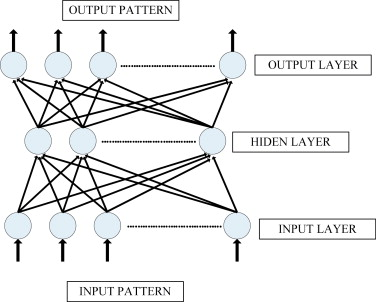

1. [Download : Download full-size image](https://ars.els-cdn.com/content/image/1-s2.0-S1568494614004062-gr1.jpg)

Fig. 1. [Feed-forward](https://www.sciencedirect.com/topics/engineering/feedforward) network with one hidden layer.

The most influential different between Feed-Forwards and Recurrents is that Recurrents unlike the others are allowed to point backwardly to previous layer. Having stunning ability to extract patterns which, by and large, are ambiguous for us, ANNs have introduced themselves as reliable means of abstruse classifications. However because of the well-known black-box nature, their explanation capability unlike the other methods is limited.

### 4.3. K-Nearest Neighbors (KNN)

Among various classification techniques, most of them rely on many assumptions made over data but in practical cases only few of them are applicable. Beyond such methods another type of [learning algorithms](https://www.sciencedirect.com/topics/computer-science/learning-algorithm) named non-parametric learning has been introduced. These types of algorithms make no assumption on the data and therefore they are applicable on many [real world problems](https://www.sciencedirect.com/topics/computer-science/real-world-problem). K-Nearest Neighbors (KNN) is one the most applicable and useful non-parametric learning algorithms. KNN may be known as a lazy algorithm, that is, all training data are used at testing phase. In fact there is no training phase and all data points are used directly in test phase, so these all points need to be used when it is to be tested [48].

KNN uses the distance between records so as to apply it for classification. In order to measure the distance between the points, KNN assumes that these points are scalar or multidimensional vectors in feature space. [Euclidean distance](https://www.sciencedirect.com/topics/computer-science/euclidean-distance) is one of the most commonly used measuring methods used in KNN. All data points are vectors of feature space and the label will define their classes. The simplest case is when the class labels are binary but still it is applicable on arbitrary class numbers.

The classification problem for KNN can be stated as if we have some labeled data points (used for training) by which the model is trained and also some test [unlabeled data](https://www.sciencedirect.com/topics/computer-science/unlabeled-data) by which the model's performance is measured. Assume that we are to classify the test data using only one neighbor. Let the test point be *x* and name *y* for the nearest train data (labeled data) to *x*. According to a rule (nearest neighbor rule), *x* has to be labeled after *y*'s label. This may seem naive and unreliable but it has proved to work, especially when there are a large number of data points, its result improves. In cases where we talk about *k* neighbors (*k* is odd), the most straightforward way is to find the *k* nearest neighbors and assign *x* to the class in which most of *k* neighbors vote for it. For example let *k* = 5, three neighbors of *x* are of class C1 and two of them C2. According to KNN rule *x* is labeled as C1. This is obviously the simplest way and one extension as it is to do a weighted voting. One way to weigh the votes is to simply multiply it by inverse of its distance to *x*; this means the nearer the neighbor is the higher votes it has.

### 4.4. Support Vector Machine (SVM)

[Support Vector Machine](https://www.sciencedirect.com/topics/computer-science/support-vector-machine) (SVM) was first introduced by Vapnik [49]. The basic version of classifier would deal with two-class problems in which the training data are divided into two classes using a [hyperplane](https://www.sciencedirect.com/topics/engineering/hyperplanes) which is defined by a number of support vectors. It was based on the Structural [Risk Minimization](https://www.sciencedirect.com/topics/computer-science/risk-minimization) (SRM) principle stated in computational learning theory. The basic idea behind supervised learning methods is to learn from observations. SVM endows us with a binary classifier by actually finding optimal separated hyperplanes through [nonlinear mapping](https://www.sciencedirect.com/topics/computer-science/nonlinear-mapping) of the input vectors into a high-dimensional feature space. Based on support vectors, SVM constructs linear models to estimate the decision function by taking the advantage of the nonlinear class boundaries. In case the training data are linearly separable, SVM results in the optimal hyperplane with maximum distance between the hyperplane and those training sample which are closest to the hyperplane. These samples with minimum distance to the hyperplane are called support vectors. SVM only uses support vectors so as to find the hyperplane and so all other training samples are irrelevant. When the data are not linearly separable SVM uses nonlinear machines to find a hyperplane based on the minimum training error criterion [50].

In order to illustrate how SVM works we assume the simplest case where there are only two linearly separable classes. Label the training data by ${xi,yi},i=1,…l,yi∈{−1,1},xi∈ℝd$. Suppose we have some hyperplane which separates positive from negative examples. The points *x* which lie on the hyperplane satisfy the equation: $w⋅x+b=0$, *w* is normal to the hyperplane, $|b|/w$ is the [perpendicular distance](https://www.sciencedirect.com/topics/engineering/perpendicular-distance) from the hyperplane to the origin, and $w$ is the [Euclidean norm](https://www.sciencedirect.com/topics/computer-science/euclidean-norm) of *w*. Let *d*<sub>+</sub> (*d*<sub>−</sub>) be the shortest distance from the separating hyperplane to the closest positive (negative) example. Define the “margin” of a separating hyperplane to be *d*<sub>+</sub> + *d*<sub>−</sub> [51]. Such case is shown in Fig. 2. For this particular case the algorithm simply looks for the separating hyperplane with maximum margin. It is formulated as follows, satisfying these constraints on all the training data:(1)$xi⋅w+b≥+1foryi=+1$(2)$xi⋅w+b≤−1foryi=−1$which is restated such:(3)$yi(xi.w+b)−1≥0∀i$

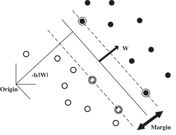

1. [Download : Download full-size image](https://ars.els-cdn.com/content/image/1-s2.0-S1568494614004062-gr2.jpg)

Fig. 2. Linear separating hyperplanes for the separable case [51].

The support vectors where the equality in Eq. (1) holds lie on the hyperplane $H1:xi⋅w+b=+1$ with normal *w* and perpendicular distance from the origin $|1−b|/w$. Similarly the support vectors, for which the equality in Eq. (2) holds, lie on the hyperplane $H2:xi⋅w+b=−1$, with again normal *w*, and perpendicular distance from the origin $|−1−b|/w$. Hence $d+=d−=1/w$ and the margin is simply $2/w$ [51]. Obviously *H*<sub>1</sub> and *H*<sub>2</sub> are parallel and no training points are between them. Thus minimizing $w2$, subject to constraints Eq. (3) leads us to finding hyperplane pairs with maximum margin.

The minimization is done using [Lagrangian multipliers](https://www.sciencedirect.com/topics/computer-science/lagrangian-multiplier) mainly because the constraint Eq. (3) can be used easily to reformulate the problem and all the training data will only appear in the form of dot products between vectors [51]. What if the training points are not linearly separable? In such cases we introduce [Kernel Functions](https://www.sciencedirect.com/topics/computer-science/kernel-function) which transform the problem to a high dimensional space in which the points in that are linearly separable. The decision function without using kernel is in the form stated in the Eq. (4) but in case the data are not linearly separable, it is transformed into a high [dimensional feature space](https://www.sciencedirect.com/topics/computer-science/dimensional-feature-space) in the form stated in Eq. (5).(4)$Y=sign∑i=1Nyiαi(x⋅xi)+b$(5)$Y=sign∑i=1NyiαiK(x,xi)+b$In Eq. (5) the function *K*(*x*, *x*<sub>*i*</sub>) is the kernel function which transforms the training data into a high dimensional feature space and only deals with dot product of the input samples. The vector *x* = (*x*<sub>1</sub>, *x*<sub>2</sub>, *x*<sub>3</sub>, …, *x*<sub>*n*</sub>) is the input and the vectors *x*<sub>*i*</sub>, *i* = 1, …, *N* are support vectors. Also *b* and *α*<sub>*i*</sub> are the parameters determining the hyperplane. Common types of Kernel functions are Polynomial, [Radial Basis Function](https://www.sciencedirect.com/topics/computer-science/radial-basis-function) (RBF) and Neural Network kernel functions.

Using Kernel functions, the input data are transformed into a high dimensional feature space and in many complex cases it makes the feature space easy to classify and in the case of telecommunication churn prediction, number of features are numerous and it is a good idea to use Kernel functions to make them easy-to-handle.

## 5. Experiments

In the previous section, we introduce 4 different and prominent [classification techniques](https://www.sciencedirect.com/topics/computer-science/classification-technique). In order to evaluate and compare these techniques normally they have to undergo a performance evaluation procedure. As it is presented in Fig. 3, the whole data have been separated into two train and test sets. Usually train set comprises 70% of data set and consequently test set is 30% of it. A classifier which has been trained by train set will be used so as to predict test set records. Finally, using a lot of known evaluation measures, for instance misclassification, the predicted values will be compared to real value of test set.

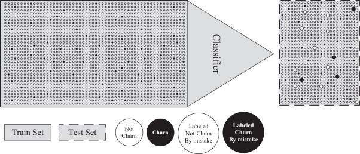

1. [Download : Download full-size image](https://ars.els-cdn.com/content/image/1-s2.0-S1568494614004062-gr3.jpg)

Fig. 3. Presentation of a classification experience.

### 5.2. Evaluation measures

In terms of [binary classification](https://www.sciencedirect.com/topics/computer-science/binary-classification) there are known measures to check the accuracy or performance of a classifier. They range from as simple as accuracy or misclassification measures to precision and recall which can show more insightful information about the performance of classifiers. Obviously there is not a better or more eligible classifier for all the cases and a [data mining](https://www.sciencedirect.com/topics/computer-science/data-mining) practitioner normally chooses one of them based on his/her needs. That is to say, understanding different classifiers will make it easy to grasp the meaning of the various measures. The following is the short description for these known measures.

Table 2. [Confusion matrix](https://www.sciencedirect.com/topics/computer-science/confusion-matrix), shown with totals for positive and negative tuples.

|  |  | Predicted class Yes | Predicted class No | Total |
| --- | --- | --- | --- | --- |
| Actual class | Yes | *TS* | *FN* | P |
|  | No | *FP* | *TN* | N |
| Total |  | $P¯$ | $N¯$ |  |

The accuracy and miscalculation of a classifier's result on a given test set are concerned with the percentage of test set tuples that are correctly or incorrectly classified, whereas precision and recall are known respectively as a measure of exactness and completeness. As it mentioned before it is highly related to the case of classification to opt for one of these measures. Since this paper classification is about the question of predicting whether a customer churn or not in order to make a decision about taking proper retention actions, in this case, we argue that precision and recall are more eligible measures. As it has been repeatedly mentioned in the literature, normally the cost of losing a valuable customer is far more than taking preventive or retention actions. And since important and valuable customers are normally taken into consideration of churn classifications, the exactness and completeness of classification performance is of our interest. In other words, if an actual non-churn is classified as churn by the classifier it is not favorable but do not cause a big loss on the other hand knowing an actual churn for a non-churn can bring about a steep loss by relying on the outcome of the classifier. All in all, to conform to this paper assumptions and case of study we have used precision and recall measures in order to evaluate the performance of every classifier in this paper.

### 5.3. DT

In order to examine the powerfulness or in other word responsiveness of [decision trees](https://www.sciencedirect.com/topics/computer-science/decision-trees) dealing with churn classification problem we tried to construct decision trees with most of available and frequently in use software in data mining environment. We built the following completed block design ANOVA (Table 3), first to examine the responsiveness of decision trees handling churn prediction problem, and then to compare the current software. There are three values for each cell in the ANOVA table which are respectively, from the left, the value of recall (RE), precision (PR) measure and misclassification (MI) for each decision tree run.

Table 3. Prediction experiments by [decision trees](https://www.sciencedirect.com/topics/computer-science/decision-trees).

| Experiments | 1 RE | 1 PR | 1 MI | 2 RE | 2 PR | 2 MI | 3 RE | 3 PR | 3 MI | 4 RE | 4 PR | 4 MI | 5 RE | 5 PR | 5 MI |
| --- | --- | --- | --- | --- | --- | --- | --- | --- | --- | --- | --- | --- | --- | --- | --- |
| MATLAB | 0.83 | 0.80 | 55 | 0.82 | 0.77 | 63 | 0.82 | 0.83 | 51 | 0.74 | 0.85 | 58 | 0.82 | 0.83 | 52 |
| R (*Part*) | 0.40 | 0.97 | 90 | 0.75 | .78 | 69 | 0.51 | 0.93 | 78 | 0.62 | 0.86 | 71 | 0.49 | 0.88 | 86 |
| R (*rparty*) | 0.78 | 0.75 | 71 | 0.77 | 0.73 | 76 | 0.77 | 0.73 | 76 | 0.8 | 0.72 | 74 | 0.67 | 0.83 | 68 |
| WEKA (*AD.Tree*) | 0.61 | 0.73 | 92 | 0.36 | 0.92 | 101 | 0.41 | 0.82 | 110 | 0.38 | 0.97 | 95 | 0.61 | 0.72 | 93 |
| WEKA (*BF.Tree*) | 0.79 | 0.86 | 52 | 0.75 | 0.84 | 58 | 0.77 | 0.86 | 58 | 0.81 | 0.93 | 38 | 0.76 | 0.78 | 66 |
| WEKA (*FT*) | 0.78 | 0.86 | 52 | 0.83 | 0.79 | 59 | 0.75 | 0.86 | 61 | 0.75 | 0.86 | 55 | 0.78 | 0.81 | 60 |
| WEKA (*J48*) | 0.83 | 0.80 | 57 | 0.85 | 0.77 | 61 | 0.71 | 0.90 | 61 | 0.78 | 0.92 | 41 | 0.77 | 0.87 | 52 |
| WEKA (*LADTree*) | 0.69 | 0.70 | 90 | 0.66 | 0.76 | 84 | 0.69 | 0.79 | 81 | 0.72 | 0.69 | 90 | 0.66 | 0.80 | 76 |
| WEKA (*LMT*) | 0.81 | 0.88 | 46 | 0.84 | 0.81 | 52 | 0.78 | 0.89 | 53 | 0.78 | 0.92 | 43 | 0.83 | 0.87 | 44 |
| WEKA (*NBTree*) | 0.77 | 0.83 | 59 | 0.81 | 0.77 | 62 | 0.67 | 0.93 | 59 | 0.69 | 0.78 | 62 | 0.71 | 0.88 | 58 |
| WEKA (*Random Forest*) | 0.79 | 0.90 | 45 | 0.83 | 0.90 | 41 | 0.81 | 0.94 | 39 | 0.83 | 0.91 | 38 | 0.81 | 0.89 | 44 |
| WEKA (*Random Tree*) | 0.75 | 0.79 | 68 | 0.82 | 0.82 | 55 | 0.79 | 0.85 | 56 | 0.75 | 0.87 | 54 | 0.76 | 0.83 | 60 |
| WEKA (*REPTree*) | 0.78 | 0.81 | 60 | 0.78 | 0.71 | 73 | 0.81 | 0.84 | 55 | 0.67 | 0.89 | 62 | 0.76 | 0.83 | 59 |
| WEKA (*Simple Cart*) | 0.85 | 0.85 | 46 | 0.75 | 0.87 | 55 | 0.83 | 0.88 | 45 | 0.78 | 0.93 | 42 | 0.83 | 0.80 | 57 |

ANOVA completed block design results (Appendix A) for both *F*-Score and Misclassification measures depicted that there is significant different in performance of all decision trees. It means that some of them have meaningfully done better job. WEKA (*[Random Forest](https://www.sciencedirect.com/topics/computer-science/random-decision-forest)*) shows to be the most responsive decision tree for churn prediction. Although, MATLAB decision performance was not as good a classifier as a few of the WEKA decision trees were, its performance was acceptable and was among good ones.

### 5.4. ANN

In this paper, [Artificial Neural Network](https://www.sciencedirect.com/topics/computer-science/artificial-neural-network) is employed in quest of identifying the best fitted network for the special characteristics of churn prediction problem. This paper dataset comprises 12 attributes: 11 attributes are inputs and one of them (churn) is the output. In order to find the best network for churn prediction purpose we built both one hidden and two hidden layers networks and observed their performances. For each and every number of neurons in one hidden layer and also for each and every combination of the numbers for neurons in two-hidden-layers networks we randomly prepared 10 new experiments (training and test set). Table 4, Table 5 are the average *F*-Score measure for each 10 experiences.

Table 4. *F*-Score results for the each number of neurons in one-hidden-layer networks.

| N. neurons | 1 | 2 | 3 | 4 | 5 | 6 | 7 | 8 | 9 | 10 |
| --- | --- | --- | --- | --- | --- | --- | --- | --- | --- | --- |
| *F*-Score | 0.681 | 0.669 | 0.706 | 0.694 | 0.778 | 0.756 | 0.801 | 0.787 | 0.783 | 0.681 |

| N. neurons | 11 | 12 | 13 | 14 | 15 | 16 | 17 | 18 | 19 | 20 |
| --- | --- | --- | --- | --- | --- | --- | --- | --- | --- | --- |
| *F*-Score | 0.829 | 0.811 | 0.799 | 0.834 | 0.835 | 0.833 | 0.788 | 0.839 | **0.845** | 0.835 |

Table 5. *F*-Score results for the each combination for the number of neurons in two-hidden-layer networks.

| N. neurons | 1 | 2 | 3 | 4 | 5 | 6 | 7 | 8 | 9 | 10 | 11 | 12 | 13 | 14 | 15 |
| --- | --- | --- | --- | --- | --- | --- | --- | --- | --- | --- | --- | --- | --- | --- | --- |
| 1 | 0.662 | 0.659 | 0.642 | 0.609 | 0.679 | 0.657 | 0.561 | 0.621 | 0.598 | 0.626 | 0.661 | 0.6 | 0.552 | 0.652 | 0.573 |
| 2 | 0.675 | 0.652 | 0.666 | 0.671 | 0.752 | 0.705 | 0.657 | 0.74 | 0.68 | 0.762 | 0.753 | 0.733 | 0.733 | 0.659 | 0.745 |
| 3 | 0.675 | 0.697 | 0.671 | 0.703 | 0.747 | 0.783 | 0.743 | 0.727 | 0.702 | 0.76 | 0.773 | 0.783 | 0.792 | 0.765 | 0.793 |
| 4 | 0.736 | 0.854 | 0.677 | 0.735 | 0.808 | 0.765 | 0.755 | 0.772 | 0.801 | 0.815 | 0.825 | 0.816 | 0.795 | 0.813 | 0.749 |
| 5 | 0.71 | 0.742 | 0.774 | 0.795 | 0.826 | 0.771 | 0.753 | 0.828 | 0.842 | 0.823 | 0.822 | 0.849 | 0.836 | 0.828 | 0.818 |
| 6 | 0.75 | 0.755 | 0.772 | 0.789 | 0.755 | 0.819 | 0.813 | 0.822 | 0.786 | 0.833 | 0.774 | 0.823 | 0.823 | 0.823 | 0.83 |
| 7 | 0.775 | 0.793 | 0.784 | 0.744 | 0.765 | 0.808 | 0.747 | 0.824 | 0.841 | 0.83 | 0.843 | 0.829 | 0.842 | 0.829 | 0.847 |
| 8 | 0.789 | 0.803 | 0.845 | 0.789 | 0.791 | 0.81 | 0.841 | 0.783 | 0.857 | 0.828 | **0.877** | 0.847 | 0.845 | 0.789 | 0.851 |
| 9 | 0.783 | 0.784 | 0.791 | 0.8 | 0.807 | 0.811 | 0.85 | 0.83 | 0.758 | 0.854 | 0.825 | **0.87** | 0.841 | 0.838 | 0.863 |
| 10 | 0.769 | 0.755 | 0.699 | 0.821 | 0.777 | 0.805 | 0.817 | 0.845 | 0.828 | 0.852 | 0.828 | 0.857 | 0.836 | 0.829 | 0.808 |
| 11 | 0.778 | 0.756 | 0.745 | 0.784 | 0.821 | 0.787 | 0.798 | 0.795 | 0.841 | **0.871** | 0.852 | 0.775 | 0.816 | 0.872 | 0.837 |
| 12 | 0.784 | 0.831 | 0.826 | 0.798 | 0.752 | 0.833 | 0.814 | 0.86 | 0.783 | 0.858 | 0.836 | 0.86 | 0.865 | 0.863 | 0.84 |
| 13 | 0.78 | 0.773 | 0.811 | 0.812 | 0.796 | 0.792 | 0.833 | 0.824 | 0.83 | 0.772 | 0.835 | 0.799 | 0.854 | 0.855 | 0.86 |
| 14 | 0.651 | 0.73 | 0.786 | 0.813 | 0.844 | 0.806 | 0.783 | 0.804 | 0.839 | 0.867 | 0.824 | 0.811 | 0.829 | 0.859 | 0.858 |
| 15 | 0.701 | 0.722 | 0.73 | 0.84 | 0.688 | 0.789 | 0.807 | 0.82 | 0.82 | 0.86 | 0.861 | 0.843 | 0.859 | **0.867** | 0.862 |

### 5.5. KNN

The other [data mining technique](https://www.sciencedirect.com/topics/computer-science/data-mining-techniques) that has been applied to this paper dataset is KNN. It is among those techniques which radically needs beforehand tuning. The tuning parameters of KNN model using cross-validation are presented in Table 6. This table reports the *F*-Scores calculated using the number of neighbors and method of distance calculation. The results showed that using cosine distance method along with 1 neighbor has led to the best *F*-Score gained by KNN.

Table 6. KNN tuning.

|  | 1 | 2 | 3 | 4 | 5 | 6 | 7 | 8 | 9 | 10 |
| --- | --- | --- | --- | --- | --- | --- | --- | --- | --- | --- |
| Euclidean | 0.5119 | 0.5119 | 0.4170 | 0.4170 | 0.3968 | 0.3695 | 0.3592 | 0.3362 | 0.2819 | 0.2489 |
| City block | 0.5544 | 0.5544 | 0.4981 | 0.4747 | 0.4615 | 0.4219 | 0.4351 | 0.4309 | 0.3821 | 0.3739 |
| Cosine | **0.7343** | 0.7343 | 0.7168 | 0.7189 | 0.7007 | 0.7119 | 0.7079 | 0.7113 | **0.7317** | 0.7234 |
| Correlation | 0.7178 | 0.7178 | 0.7247 | 0.7128 | 0.7083 | 0.7148 | 0.6920 | 0.7067 | 0.7298 | 0.7298 |

### 5.6. SVM

As it mentioned before SVM has several parameters to be tuned before final usage. So as to specify them, we applied cross-validation tuning for SVM parameters. The best *F*-Score achieved by SVM was 0.8383. The summary table for the final result of different kernel on test data is shown in Table 7. Our experience proved that the best tuning of parameter for this paper classification problem is applying polynomial kernel with order of 4. This has been used, from now on, whenever SVM is mentioned.

Table 7. SVM summary tuning.

| Kernel type | Best *F*-Score | Kernel params |
| --- | --- | --- |
| RBF | 0.821 | Sigma = 0.498 |
| MLP | 0.6618 | *P*1 = 0.11, *P*2 = −1.61 |
| Polynomial | 0.8383 | Order = 4 |

### 5.7. Comparison

So far we have introduced 4 different [soft computing techniques](https://www.sciencedirect.com/topics/computer-science/soft-computing-technique) for churn prediction. Except for decision tree, other soft-computing techniques’ demeanors were observed and consequently tuned to be adapted to the spirit of churn prediction problem in their best ways. This part of paper's aim is to compare the performances and the demeanors of all of them. Table 8 shows a complete block design table in which all of the introduced soft computing techniques results (*F*-Scores) for the aforementioned blocks are presented. Except for block 3 in which SVM has slightly outperformed ANN, it has been ANN that has had the best results. Table 9, Table 10 are respectively summary and the ANOVA complete block design analysis result for the techniques. The ANOVA results (Table 10) as it could be predicted, have rejected the hypothesis that the performances of different techniques approaching churn prediction are similar (*p*-value ≪ 0.05). Furthermore, if we are to compare the experience techniques so as to choose the best one, we simply see the Average and variance results of each technique. One may rank these techniques by the value of average (descending) and by the value of variance (ascending) respectively as follows: for Average: ANN, Best DT, SVM and KNN. For variance: Best DT, ANN, KNN, and SVM. Because of KNN the worse Validity (lower average) and its undesirable reliability (3rd variance) it is not being chosen as the best technique is beyond doubt. The value of Best DT's variance indicates its best reliability among the other techniques. Nevertheless because of its lower value of average comparing to ANN, which shows less validity, it simply cannot be chosen as the best technique. Although Best DT and SVM had performed roughly the same, the Best DT's value of variance is much more desirable. All in all, in view of the highest accuracy of ANN and its acceptable variance value among the others, ANN can be chosen as the best techniques among the others.

Table 8. Complete block design table for comparison between DT, ANN, KNN and SVM.

| Experiment | 1 | 2 | 3 | 4 | 5 |
| --- | --- | --- | --- | --- | --- |
| Best DT | 0.843 | 0.824 | 0.831 | 0.844 | 0.849 |
| ANN | 0.881 | 0.871 | 0.857 | 0.851 | 0.851 |
| KNN | 0.723 | 0.742 | 0.744 | 0.763 | 0.773 |
| SVM | 0.806 | 0.831 | 0.860 | 0.823 | 0.823 |

Table 9. Summary for Table 8.

| Summary | Count | Sum | Average | Variance |
| --- | --- | --- | --- | --- |
| Best DT | 5 | 4.191 | 0.8382 | 0.000107 |
| ANN | 5 | 4.311 | 0.8622 | 0.000177 |
| KNN | 5 | 3.745 | 0.749 | 0.000381 |
| SVM | 5 | 4.143 | 0.8286 | 0.000391 |

Table 10. ANOVA complete block design result for Table 8.

[output not shown]

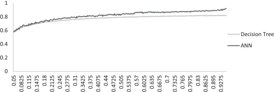

1. [Download : Download full-size image](https://ars.els-cdn.com/content/image/1-s2.0-S1568494614004062-gr4.jpg)

Fig. 4. Plot of *F*-score versus train set proportion (DT-MATLAB and ANN).

### 5.8. Feature extraction

Table 11. Features abbreviations.

| Number of fail calls | CF | Frequency of use | FU |
| --- | --- | --- | --- |
| Complaints | Co | Frequency of SMS | FS |
| Subscription length | SL | Distinct call numbers | DCN |
| Charge amount | CA | Age group | AG |
| Second of use | SU | Type of service | TS |
| Status | St |  |  |

Table 12. Feature extraction – sets of one feature.

|  | Fe | Number | Sum | Average |
| --- | --- | --- | --- | --- |
| 1 | FU | 1024 | 725.8586 | 0.708846 |
| 2 | Co | 1024 | 722.621 | 0.705685 |
| 3 | SU | 1024 | 719.3543 | 0.702494 |
| 4 | St | 1024 | 707.559 | 0.690976 |
| 5 | SL | 1024 | 702.5501 | 0.686084 |
| 6 | DCN | 1024 | 699.0004 | 0.682618 |
| 7 | AG | 1024 | 693.7532 | 0.677493 |
| 8 | CF | 1024 | 690.6193 | 0.674433 |
| 9 | FS | 1024 | 688.2293 | 0.672099 |
| 10 | CA | 1024 | 682.9907 | 0.666983 |
| 11 | TS | 1024 | 671.0787 | 0.65535 |

In order to extract more interesting insights we calculated the average influences for set of 2–6 features. Table 13 represents the top ten most influential set of features. All of the top ten sets of features were from set of 6 features which indicates that using another feature might become influential. However, to check the results of most influential set of 2–6 features see Appendix B.

Table 13. Feature extraction – top ten with maximum average among set of 1–6 features (total number of features set is 1485).

|  | Fe 1 | Fe 2 | Fe 3 | Fe 4 | Fe 5 | Fe 6 | Number | Sum | Average |
| --- | --- | --- | --- | --- | --- | --- | --- | --- | --- |
| 1 | Co | SL | SU | DCN | AG | St | 32 | 25.99895 | 0.812467 |
| 2 | Co | SL | SU | FU | AG | St | 32 | 25.98944 | 0.81217 |
| 3 | CF | Co | SL | SU | AG | St | 32 | 25.85625 | 0.808008 |
| 4 | CF | Co | SL | FU | AG | St | 32 | 25.84574 | 0.807679 |
| 5 | Co | SL | FU | DCN | AG | St | 32 | 25.83967 | 0.80749 |
| 6 | Co | SL | SU | FU | DCN | AG | 32 | 25.76135 | 0.805042 |
| 7 | CF | Co | SL | SU | FU | AG | 32 | 25.72194 | 0.803811 |
| 8 | Co | SL | SU | FU | DCN | St | 32 | 25.69614 | 0.803004 |
| 9 | CF | Co | SL | SU | FU | St | 32 | 25.68352 | 0.80261 |
| 10 | CF | Co | SL | SU | DCN | St | 32 | 25.64151 | 0.801297 |

## 6. Proposed methodology

So far we have discussed and experienced 4 prominent [data mining](https://www.sciencedirect.com/topics/computer-science/data-mining) [classification techniques](https://www.sciencedirect.com/topics/computer-science/classification-technique) and all of them showed different demeanors. It was mentioned earlier that the proportion of churn data is usually too small for a train-set system. As it was seen earlier in the plot presented in Fig. 4 DT or ANN performances did not drop dramatically by decreasing the train-set proportion of data. Therefore, here in the proposed methodology we have come up with the idea of using all of 4 experienced classifiers to make a better and more accurate hybrid classifier. One can see the general idea behind our proposed methodology by contemplating Fig. 5.

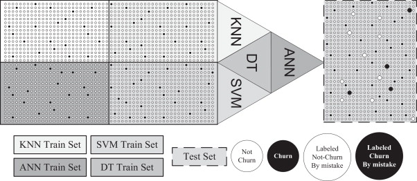

1. [Download : Download full-size image](https://ars.els-cdn.com/content/image/1-s2.0-S1568494614004062-gr5.jpg)

Fig. 5. Proposed methodology.

Table 14. Scores assignment.

|  | Count | Sum | Average (*A*) | Variance (*V*) | Validity (*Va*) | Reliability (*Re*) | Scores (*S*<sub>*i*</sub>) |
| --- | --- | --- | --- | --- | --- | --- | --- |
| DT | 5 | 4.050072 | 0.810014 | 0.000268 | 0.249249 | 0.259929 | 2.5 |
| ANN | 5 | 4.311 | 0.8622 | 0.000177 | 0.265307 | 0.284853 | 2.8 |
| KNN | 5 | 3.745 | 0.749 | 0.000381 | 0.230475 | 0.228978 | 2.3 |
| SVM | 5 | 4.143 | 0.8286 | 0.000391 | 0.254968 | 0.226239 | 2.4 |
| Sum |  |  |  |  | 1 | 1 | 10 |

Table 15. Proposed methodology outcome with *ϕ* variation.

| *ϕ* | 0.5 RE | 0.5 PR | 0.5 FS | 0.7 RE | 0.7 PR | 0.7 FS | 0.9 RE | 0.9 PR | 0.9 FS | 1 RE | 1 PR | 1 FS |
| --- | --- | --- | --- | --- | --- | --- | --- | --- | --- | --- | --- | --- |
| Block 1 | 0.317 | 1 | 0.482 | 0.662 | 0.837 | 0.739 | 0.709 | 0.847 | 0.772 | 0.797 | 0.837 | 0.817 |
| Block 2 | 0.290 | 1 | 0.450 | 0.635 | 0.969 | 0.767 | 0.689 | 0.918 | 0.787 | 0.790 | 0.921 | 0.851 |
| Block 3 | 0.378 | 1 | 0.549 | 0.736 | 0.893 | 0.807 | 0.770 | 0.877 | 0.82 | 0.898 | 0.887 | 0.893 |
| Block 4 | 0.385 | 1 | 0.556 | 0.662 | 0.961 | 0.784 | 0.757 | 0.941 | 0.839 | 0.817 | 0.864 | 0.84 |
| Block 5 | 0.263 | 0.928 | 0.41 | 0.641 | 0.896 | 0.748 | 0.655 | 0.851 | 0.740 | 0.790 | 0.847 | 0.818 |

| *ϕ* | 1.25 RE | 1.25 PR | 1.25 FS | 1.5 RE | 1.5 PR | 1.5 FS | 1.8 RE | 1.8 PR | 1.8 FS | 2.2 RE | 2.2 PR | 2.2 FS |
| --- | --- | --- | --- | --- | --- | --- | --- | --- | --- | --- | --- | --- |
| Block 1 | 0.824 | 0.797 | 0.811 | 0.824 | 0.797 | 0.811 | 0.844 | 0.801 | 0.822 | 0.966 | 0.821 | 0.888 |
| Block 2 | 0.878 | 0.769 | 0.820 | 0.878 | 0.769 | 0.820 | 0.891 | 0.771 | 0.827 | 0.966 | 0.773 | 0.859 |
| Block 3 | 0.912 | 0.808 | 0.857 | 0.912 | 0.808 | 0.857 | 0.932 | 0.811 | 0.868 | 0.98 | 0.784 | 0.871 |
| Block 4 | 0.858 | 0.765 | 0.809 | 0.858 | 0.765 | 0.808 | 0.878 | 0.769 | 0.82 | 0.966 | 0.748 | 0.844 |
| Block 5 | 0.905 | 0.779 | 0.837 | 0.905 | 0.779 | 0.837 | 0.926 | 0.783 | 0.848 | 0.979 | 0.784 | 0.871 |

## 7. Conclusion and future research

Table 16. Comparing recall value of hybrid methodology.

|  | 1 | 2 | 3 | 4 | 5 |
| --- | --- | --- | --- | --- | --- |
| Best DT | 0.787 | 0.834 | 0.814 | 0.828 | 0.809 |
| ANN | 0.908 | 0.891 | 0.869 | 0.874 | 0.869 |
| KNN | 0.706 | 0.725 | 0.727 | 0.748 | 0.743 |
| SVM | 0.923 | 0.932 | 0.912 | 0.931 | 0.939 |
| Best hybrid methodology | 0.966 | 0.966 | 0.98 | 0.966 | 0.979 |

Table 17. Comparing precision value of hybrid methodology.

|  | 1 | 2 | 3 | 4 | 5 |
| --- | --- | --- | --- | --- | --- |
| Best DT | 0.903 | 0.901 | 0.936 | 0.914 | 0.895 |
| ANN | 0.857 | 0.852 | 0.845 | 0.823 | 0.838 |
| KNN | 0.741 | 0.76 | 0.762 | 0.780 | 0.809 |
| SVM | 0.715 | 0.761 | 0.813 | 0.734 | 0.731 |
| Best hybrid methodology | 1 | 1 | 1 | 1 | 0.928 |

Additionally, we introduced a new [dimensionality reduction](https://www.sciencedirect.com/topics/computer-science/dimensionality-reduction) methodology so as to extract the most influential set of features. Frequency of use, total number of complaints, and seconds of use were shown to be the influential ones. Also on the contrary of the previous study on the same data set, we showed that frequency of SMS, charge amount and type of service were the least influential ones. Finally it can be concluded that the high value of Recall and Precision obtained by the hybrid methodology is due to the application of four different insights, four different classifiers. Not only this paper methodology for churn analysis can be used by telecommunication companies seeking for an accurate prediction, it can also be tested in other areas of business which deals with everyday customers. The analogy for this paper is the idea of four different experts (classifiers) expressing their opinions; so one researcher may approach this paper model by fuzzy logic for a decision-making procedure.

## Appendix A.

See Table 18, Table 19, Table 20, Table 21, Table 22, Table 23.

Table 18. Complete block design ANOVA for the performance of different [decision trees](https://www.sciencedirect.com/topics/computer-science/decision-trees) using *F*-Score measure.

| Experiment | 1 | 2 | 3 | 4 | 5 |
| --- | --- | --- | --- | --- | --- |
| MATLAB | 0.814 | 0.794 | 0.824 | 0.791 | 0.824 |
| R (*Part*) | 0.566 | 0.765 | 0.659 | 0.720 | 0.629 |
| R (*rparty*) | 0.765 | 0.749 | 0.749 | 0.758 | 0.741 |
| WEKA (*AD.Tree*) | 0.664 | 0.517 | 0.547 | 0.546 | 0.660 |
| WEKA (*BF.Tree*) | 0.823 | 0.792 | 0.812 | 0.865 | 0.769 |
| WEKA (*FT*) | 0.818 | 0.809 | 0.801 | 0.801 | 0.795 |
| WEKA (*J48*) | 0.815 | 0.808 | 0.794 | 0.844 | 0.816 |
| WEKA (*LADTree*) | 0.695 | 0.706 | 0.737 | 0.704 | 0.723 |
| WEKA (*LMT*) | 0.843 | 0.824 | 0.831 | 0.844 | 0.849 |
| WEKA (*NBTree*) | 0.798 | 0.789 | 0.779 | 0.732 | 0.785 |
| WEKA (*Random Forest*) | 0.841 | 0.863 | 0.870 | 0.868 | 0.848 |
| WEKA (*Random Tree*) | 0.769 | 0.82 | 0.819 | 0.805 | 0.793 |
| WEKA (*REPTree*) | 0.795 | 0.743 | 0.825 | 0.764 | 0.793 |
| WEKA (*Simple Cart*) | 0.85 | 0.805 | 0.854 | 0.848 | 0.815 |

Table 19. Completed block design ANOVA (summary) – [decision trees](https://www.sciencedirect.com/topics/computer-science/decision-trees) – *F*-Score.

| Summary | Count | Sum | Average | Variance |
| --- | --- | --- | --- | --- |
| MATLAB | 5 | 4.050072 | 0.810014 | 0.000268 |
| R (*Part*) | 5 | 3.339909 | 0.667982 | 0.006 |
| R (*rparty*) | 5 | 3.763001 | 0.7526 | 7.95E-05 |
| WEKA (*AD.Tree*) | 5 | 2.935319 | 0.587064 | 0.004888 |
| WEKA (*BF.Tree*) | 5 | 4.064216 | 0.812843 | 0.001297 |
| WEKA (*FT*) | 5 | 4.024756 | 0.804951 | 8.11E-05 |
| WEKA (*J48*) | 5 | 4.077724 | 0.815545 | 0.000339 |
| WEKA (*LADTree*) | 5 | 3.566033 | 0.713207 | 0.000275 |
| WEKA (*LMT*) | 5 | 4.19342 | 0.838684 | 0.000105 |
| WEKA (*NBTree*) | 5 | 3.885401 | 0.77708 | 0.00068 |
| WEKA (*Random Forest*) | 5 | 4.291454 | 0.858291 | 0.000164 |
| WEKA (*Random Tree*) | 5 | 4.007398 | 0.80148 | 0.000438 |
| WEKA (*REPTree*) | 5 | 3.920746 | 0.784149 | 0.000974 |
| WEKA (*Simple Cart*) | 5 | 4.17297 | 0.834594 | 0.000513 |

Table 20. Completed block design ANOVA – [decision trees](https://www.sciencedirect.com/topics/computer-science/decision-trees) – *F*-Score.

| Source of variation | *SS* | *df* | *MS* | *F* | *p*-Value | *F* crit |
| --- | --- | --- | --- | --- | --- | --- |
| Decision Trees | 0.358103 | 13 | 0.027546 | 22.44405 | 7.91E−17 | 1.913455 |
| Blocks | 0.000587 | 4 | 0.000147 | 0.11947 | 0.974968 |  |
| Error | 0.063822 | 52 | 0.001227 |  |  |  |
| Total | 0.422511 | 69 |  |  |  |  |

Table 21. Complete block design ANOVA for the performance of different [decision trees](https://www.sciencedirect.com/topics/computer-science/decision-trees) using [Misclassification](https://www.sciencedirect.com/topics/engineering/misclassification).

| Experiment | 1 | 2 | 3 | 4 | 5 |
| --- | --- | --- | --- | --- | --- |
| MATLAB | 55 | 63 | 51 | 58 | 52 |
| R (*Part*) | 90 | 69 | 78 | 71 | 86 |
| R (*rparty*) | 71 | 76 | 76 | 74 | 68 |
| WEKA (*AD.Tree*) | 92 | 101 | 110 | 95 | 93 |
| WEKA (*BF.Tree*) | 52 | 58 | 58 | 38 | 66 |
| WEKA (*FT*) | 52 | 59 | 61 | 55 | 60 |
| WEKA (*J48*) | 57 | 61 | 61 | 41 | 52 |
| WEKA (*LADTree*) | 90 | 84 | 81 | 90 | 76 |
| WEKA (*LMT*) | 46 | 52 | 53 | 43 | 44 |
| WEKA (*NBTree*) | 59 | 62 | 59 | 62 | 58 |
| WEKA (*Random Forest*) | 45 | 41 | 39 | 38 | 44 |
| WEKA (*Random Tree*) | 68 | 55 | 56 | 54 | 60 |
| WEKA (*REPTree*) | 60 | 73 | 55 | 62 | 59 |
| WEKA (*Simple Cart*) | 46 | 55 | 45 | 42 | 57 |

Table 22. Completed block design ANOVA (summary) – [decision trees](https://www.sciencedirect.com/topics/computer-science/decision-trees) – misclassification.

| Summary | Count | Sum | Average | Variance |
| --- | --- | --- | --- | --- |
| MATLAB | 5 | 279 | 55.8 | 23.7 |
| R (*Part*) | 5 | 394 | 78.8 | 83.7 |
| R (*rparty*) | 5 | 365 | 73 | 12 |
| WEKA (*AD.Tree*) | 5 | 491 | 98.2 | 55.7 |
| WEKA (*BF.Tree*) | 5 | 272 | 54.4 | 108.8 |
| WEKA (*FT*) | 5 | 287 | 57.4 | 14.3 |
| WEKA (*J48*) | 5 | 272 | 54.4 | 69.8 |
| WEKA (*LADTree*) | 5 | 421 | 84.2 | 36.2 |
| WEKA (*LMT*) | 5 | 238 | 47.6 | 21.3 |
| WEKA (*NBTree*) | 5 | 300 | 60 | 3.5 |
| WEKA (*Random Forest*) | 5 | 207 | 41.4 | 9.3 |
| WEKA (*Random Tree*) | 5 | 293 | 58.6 | 32.8 |
| WEKA (*REPTree*) | 5 | 309 | 61.8 | 45.7 |
| WEKA (*Simple Cart*) | 5 | 245 | 49 | 43.5 |

Table 23. Completed block design ANOVA – [decision trees](https://www.sciencedirect.com/topics/computer-science/decision-trees) – misclassification.

| Source of variation | *SS* | *df* | *MS* | *F* | *p*-Value | *F* crit |
| --- | --- | --- | --- | --- | --- | --- |
| Decision trees | 15,974.24 | 13 | 1228.788 | 32.66048 | 2.09E−20 | 1.913455 |
| Blocks | 284.8 | 4 | 71.2 | 1.892456 | 0.125681 |  |
| Error | 1956.4 | 52 | 37.62308 |  |  |  |
| Total | 18,215.44 | 69 |  |  |  |  |

## Appendix B.

See Table 24, Table 25, Table 26, Table 27, Table 28.

Table 24. Feature extraction – sets of two features.

|  | Fe 1 | Fe 2 | Number | Sum | Average |
| --- | --- | --- | --- | --- | --- |
| 1 | Co | FU | 512 | 380.9361 | 0.744016 |
| 2 | Co | SU | 512 | 377.0122 | 0.736352 |
| 3 | FU | St | 512 | 376.5365 | 0.735423 |
| 4 | Co | St | 512 | 375.0804 | 0.732579 |
| 5 | SU | St | 512 | 374.5311 | 0.731506 |
| 6 | FU | AG | 512 | 374.3681 | 0.731188 |
| 7 | SL | FU | 512 | 374.1209 | 0.730705 |
| 8 | SU | FU | 512 | 372.4886 | 0.727517 |
| 9 | SL | SU | 512 | 371.9856 | 0.726534 |
| 10 | Co | SL | 512 | 371.8025 | 0.726177 |
| 11 | CF | FU | 512 | 371.7391 | 0.726053 |
| 12 | SU | AG | 512 | 371.4803 | 0.725548 |
| 13 | Co | AG | 512 | 371.3476 | 0.725288 |
| 14 | Co | DCN | 512 | 370.167 | 0.722982 |
| 15 | SL | St | 512 | 369.1976 | 0.721089 |
| 16 | FU | FS | 512 | 368.6413 | 0.720003 |
| 17 | CF | SU | 512 | 368.5819 | 0.719886 |
| 18 | CA | FU | 512 | 368.3515 | 0.719436 |
| 19 | FU | DCN | 512 | 368.1364 | 0.719016 |
| 20 | DCN | St | 512 | 366.6653 | 0.716143 |
| 21 | CF | Co | 512 | 366.4885 | 0.715798 |
| 22 | SU | DCN | 512 | 366.2183 | 0.71527 |
| 23 | Co | CA | 512 | 365.2672 | 0.713413 |
| 24 | Co | FS | 512 | 364.5545 | 0.712021 |
| 25 | CA | SU | 512 | 364.0862 | 0.711106 |
| 26 | SL | DCN | 512 | 363.7678 | 0.710484 |
| 27 | SL | AG | 512 | 363.7069 | 0.710365 |
| 28 | SU | FS | 512 | 363.3403 | 0.709649 |
| 29 | FU | TS | 512 | 363.1088 | 0.709197 |
| 30 | AG | St | 512 | 362.2521 | 0.707524 |
| 31 | CF | St | 512 | 361.8828 | 0.706802 |
| 32 | DCN | AG | 512 | 361.582 | 0.706215 |
| 33 | Co | TS | 512 | 361.389 | 0.705838 |
| 34 | CF | SL | 512 | 360.2547 | 0.703622 |
| 35 | FS | St | 512 | 360.0698 | 0.703261 |
| 36 | SU | TS | 512 | 359.9179 | 0.702965 |
| 37 | SL | FS | 512 | 359.4622 | 0.702075 |
| 38 | CF | AG | 512 | 356.3965 | 0.696087 |
| 39 | SL | CA | 512 | 356.3791 | 0.696053 |
| 40 | CF | DCN | 512 | 356.2981 | 0.695895 |
| 41 | FS | DCN | 512 | 356.1689 | 0.695642 |
| 42 | CA | St | 512 | 355.2861 | 0.693918 |
| 43 | CA | DCN | 512 | 354.4789 | 0.692342 |
| 44 | FS | AG | 512 | 354.056 | 0.691516 |
| 45 | TS | St | 512 | 353.9038 | 0.691218 |
| 46 | CA | AG | 512 | 351.8454 | 0.687198 |
| 47 | CF | CA | 512 | 351.6518 | 0.68682 |
| 48 | SL | TS | 512 | 351.443 | 0.686412 |
| 49 | CF | FS | 512 | 351.2325 | 0.686001 |
| 50 | CA | FS | 512 | 349.9558 | 0.683507 |
| 51 | DCN | TS | 512 | 349.6551 | 0.68292 |
| 52 | AG | TS | 512 | 347.0557 | 0.677843 |
| 53 | CF | TS | 512 | 345.491 | 0.674787 |
| 54 | FS | TS | 512 | 344.1315 | 0.672132 |
| 55 | CA | TS | 512 | 341.6556 | 0.667296 |

Table 25. Feature extraction – sets of three features.

|  | Fe 1 | Fe 2 | Fe 3 | Number | Sum | Average |
| --- | --- | --- | --- | --- | --- | --- |
| 1 | CF | SU | FS | 256 | 196.5769 | 0.767878 |
| 2 | CF | CA | St | 256 | 195.9482 | 0.765423 |
| 3 | CF | CA | DCN | 256 | 194.9184 | 0.7614 |
| 4 | CF | Co | SU | 256 | 194.7285 | 0.760658 |
| 5 | CF | CA | FU | 256 | 194.0358 | 0.757952 |
| 6 | CF | SL | TS | 256 | 193.7185 | 0.756713 |
| 7 | CF | Co | CA | 256 | 193.7131 | 0.756692 |
| 8 | CA | FS | St | 256 | 193.4997 | 0.755858 |
| 9 | Co | SL | TS | 256 | 193.2649 | 0.754941 |
| 10 | Co | SL | FS | 256 | 193.2363 | 0.754829 |
| 11 | Co | CA | SU | 256 | 192.9846 | 0.753846 |
| 12 | SL | SU | FS | 256 | 192.848 | 0.753312 |
| 13 | CF | Co | TS | 256 | 192.8413 | 0.753286 |
| 14 | CF | FU | AG | 256 | 192.6489 | 0.752535 |
| 15 | CF | CA | TS | 256 | 192.4778 | 0.751866 |
| 16 | Co | SL | SU | 256 | 192.4297 | 0.751678 |
| 17 | SL | TS | St | 256 | 192.4017 | 0.751569 |
| 18 | FU | TS | St | 256 | 192.3593 | 0.751403 |
| 19 | CF | SL | CA | 256 | 192.2544 | 0.750994 |
| 20 | CF | CA | AG | 256 | 191.8955 | 0.749592 |
| 21 | CF | AG | St | 256 | 191.8831 | 0.749543 |
| 22 | SU | FU | DCN | 256 | 191.5953 | 0.748419 |
| 23 | CF | Co | DCN | 256 | 191.4551 | 0.747872 |
| 24 | CA | FS | TS | 256 | 191.4283 | 0.747767 |
| 25 | SL | CA | St | 256 | 191.3618 | 0.747507 |
| 26 | SL | FU | St | 256 | 191.2842 | 0.747204 |
| 27 | CF | CA | SU | 256 | 191.2801 | 0.747188 |
| 28 | FU | AG | TS | 256 | 191.1021 | 0.746493 |
| 29 | FU | DCN | AG | 256 | 190.8747 | 0.745604 |
| 30 | CF | Co | FS | 256 | 190.7395 | 0.745076 |

[output cut: 135 more lines]

Table 26. Feature extraction – top ten with maximum average influence sets of four features.

|  | Fe 1 | Fe 2 | Fe 3 | Fe 4 | Number | Sum | Average |
| --- | --- | --- | --- | --- | --- | --- | --- |
| 1 | Co | SL | FU | AG | 128 | 100.274 | 0.78339 |
| 2 | Co | SL | FU | St | 128 | 100.1265 | 0.782238 |
| 3 | Co | SL | SU | St | 128 | 99.97759 | 0.781075 |
| 4 | Co | FU | AG | St | 128 | 99.91599 | 0.780594 |
| 5 | Co | SL | SU | AG | 128 | 99.85633 | 0.780128 |
| 6 | Co | SU | FU | St | 128 | 99.81065 | 0.779771 |
| 7 | CF | Co | FU | St | 128 | 99.58711 | 0.778024 |
| 8 | Co | SU | FU | AG | 128 | 99.43807 | 0.77686 |
| 9 | CF | Co | FU | AG | 128 | 99.27647 | 0.775597 |
| 10 | Co | FU | DCN | St | 128 | 99.25348 | 0.775418 |

Table 27. Feature extraction – top ten with maximum average influence sets of five features.

|  | Fe 1 | Fe 2 | Fe 3 | Fe 4 | Fe 5 | Number | Sum | Average |
| --- | --- | --- | --- | --- | --- | --- | --- | --- |
| 1 | Co | SL | FU | AG | St | 64 | 51.12456 | 0.798821 |
| 2 | Co | SL | SU | AG | St | 64 | 51.08254 | 0.798165 |
| 3 | Co | SL | SU | FU | AG | 64 | 51.01878 | 0.797168 |
| 4 | Co | SL | SU | FU | St | 64 | 50.95235 | 0.796131 |
| 5 | Co | SL | SU | DCN | St | 64 | 50.90555 | 0.795399 |
| 6 | CF | Co | SL | FU | AG | 64 | 50.79088 | 0.793608 |
| 7 | CF | Co | SL | FU | St | 64 | 50.74832 | 0.792943 |
| 8 | Co | SL | SU | DCN | AG | 64 | 50.70897 | 0.792328 |
| 9 | CF | Co | SL | SU | AG | 64 | 50.70111 | 0.792205 |
| 10 | Co | SL | FU | DCN | AG | 64 | 50.69537 | 0.792115 |

Table 28. Feature extraction – top ten with maximum average influence sets of six features.

|  | Fe 1 | Fe 2 | Fe 3 | Fe 4 | Fe 5 | Fe 6 | Number | Sum | Average |
| --- | --- | --- | --- | --- | --- | --- | --- | --- | --- |
| 1 | Co | SL | SU | DCN | AG | St | 32 | 25.99895 | 0.812467 |
| 2 | Co | SL | SU | FU | AG | St | 32 | 25.98944 | 0.81217 |
| 3 | CF | Co | SL | SU | AG | St | 32 | 25.85625 | 0.808008 |
| 4 | CF | Co | SL | FU | AG | St | 32 | 25.84574 | 0.807679 |
| 5 | Co | SL | FU | DCN | AG | St | 32 | 25.83967 | 0.80749 |
| 6 | Co | SL | SU | FU | DCN | AG | 32 | 25.76135 | 0.805042 |
| 7 | CF | Co | SL | SU | FU | AG | 32 | 25.72194 | 0.803811 |
| 8 | Co | SL | SU | FU | DCN | St | 32 | 25.69614 | 0.803004 |
| 9 | CF | Co | SL | SU | FU | St | 32 | 25.68352 | 0.80261 |
| 10 | CF | Co | SL | SU | DCN | St | 32 | 25.64151 | 0.801297 |

## References

**[1]**

X. Zhang, J. Zhu, S. Xu, Y. Wan**Predicting customer churn through interpersonal influence**

Knowl.-Based Syst., 28 (2012), pp. 97-104

[Article](https://www.sciencedirect.com/science/article/pii/S0950705111002693)[Download PDF](https://www.sciencedirect.com/science/article/pii/S0950705111002693/pdfft?md5=84664bde6b74648e791dc3db38f621f1&pid=1-s2.0-S0950705111002693-main.pdf)[View Record in Scopus](https://www.scopus.com/inward/record.url?eid=2-s2.0-84856230447&partnerID=10&rel=R3.0.0)[Google Scholar](https://scholar.google.com/scholar_lookup?title=Predicting%20customer%20churn%20through%20interpersonal%20influence&publication_year=2012&author=X.%20Zhang&author=J.%20Zhu&author=S.%20Xu&author=Y.%20Wan)

**[2]**

S.C. Lin, C.H. Tung, N.Y. Jan, D.A. Chiang**Evaluating churn model in CRM: a case study in Telecom**

J. Converg. Inf. Technol., 6 (2011), pp. 192-200

[View Record in Scopus](https://www.scopus.com/inward/record.url?eid=2-s2.0-82055171905&partnerID=10&rel=R3.0.0)Google Scholar

**[3]**

B. Huang, M.T. Kechadi, B. Buckley**Customer churn prediction in telecommunications**

Expert Syst. Appl., 39 (2012), pp. 1414-1425

[Article](https://www.sciencedirect.com/science/article/pii/S0957417411011353)[Download PDF](https://www.sciencedirect.com/science/article/pii/S0957417411011353/pdfft?md5=eb8ad9e8dd75f739841339618bb9ac14&pid=1-s2.0-S0957417411011353-main.pdf)[View Record in Scopus](https://www.scopus.com/inward/record.url?eid=2-s2.0-81855164826&partnerID=10&rel=R3.0.0)[Google Scholar](https://scholar.google.com/scholar_lookup?title=Customer%20churn%20prediction%20in%20telecommunications&publication_year=2012&author=B.%20Huang&author=M.T.%20Kechadi&author=B.%20Buckley)

**[4]**

W. Verbeke, K. Dejaeger, D. Martens, J. Hur, B. Baesens**New insights into churn prediction in the telecommunication sector: a profit driven data mining approach**

Eur. J. Oper. Res., 218 (2012), pp. 211-229

[Article](https://www.sciencedirect.com/science/article/pii/S0377221711008599)[Download PDF](https://www.sciencedirect.com/science/article/pii/S0377221711008599/pdfft?md5=d7bef473d8613d8e0b30f776f9bb2a67&pid=1-s2.0-S0377221711008599-main.pdf)[View Record in Scopus](https://www.scopus.com/inward/record.url?eid=2-s2.0-83955164226&partnerID=10&rel=R3.0.0)Google Scholar

**[5]**

H.M. Kuo, C.W. Chen**A novel viewpoint on information and interface design for auction web sites**

Hum. Factors Ergon. Manuf. Serv. Ind., 22 (2012), pp. 287-295

[CrossRef](https://doi.org/10.1002/hfm.20274)[View Record in Scopus](https://www.scopus.com/inward/record.url?eid=2-s2.0-84859062426&partnerID=10&rel=R3.0.0)[Google Scholar](https://scholar.google.com/scholar_lookup?title=A%20novel%20viewpoint%20on%20information%20and%20interface%20design%20for%20auction%20web%20sites&publication_year=2012&author=H.M.%20Kuo&author=C.W.%20Chen)

**[6]**

A. Keramati, R. Jafari-Marandi**Webpage clustering – taking the zero step: a case study of an Iranian website**

J. Web Eng., 13 (2014)

[Google Scholar](https://scholar.google.com/scholar?q=Webpage%20clustering%20%20taking%20the%20zero%20step:%20a%20case%20study%20of%20an%20Iranian%20website)

**[7]**

Y. Sekercioğlu, A. Pitsillides, A. Vasilakos**Computational intelligence in management of ATM networks**

Soft Comput., 5 (2001), pp. 257-263

[CrossRef](https://doi.org/10.1007/s005000100099)Google Scholar

**[8]**

A. Azadeh, S. Asadzadeh, R. Jafari-Marandi, S. Nazari-Shirkouhi, G. Baharian Khoshkhou, S. Talebi, A. Naghavi**Optimum estimation of missing values in randomized complete block design by genetic algorithm**

Knowl.-Based Syst., 37 (2013), pp. 37-47

[Article](https://www.sciencedirect.com/science/article/pii/S0950705112001852)[Download PDF](https://www.sciencedirect.com/science/article/pii/S0950705112001852/pdfft?md5=25b9fe8d5ba987099875bbb855873609&pid=1-s2.0-S0950705112001852-main.pdf)[View Record in Scopus](https://www.scopus.com/inward/record.url?eid=2-s2.0-84870053909&partnerID=10&rel=R3.0.0)Google Scholar

**[9]**

C.-W. Chen**Stability analysis and robustness design of nonlinear systems: an NN-based approach**

Appl. Soft Comput., 11 (2011), pp. 2735-2742

[Article](https://www.sciencedirect.com/science/article/pii/S1568494610002814)[Download PDF](https://www.sciencedirect.com/science/article/pii/S1568494610002814/pdfft?md5=fc3ed1a1e5126452a564e4ca355adc3a&pid=1-s2.0-S1568494610002814-main.pdf)[View Record in Scopus](https://www.scopus.com/inward/record.url?eid=2-s2.0-78751621175&partnerID=10&rel=R3.0.0)[Google Scholar](https://scholar.google.com/scholar_lookup?title=Stability%20analysis%20and%20robustness%20design%20of%20nonlinear%20systems%3A%20an%20NN-based%20approach&publication_year=2011&author=C.-W.%20Chen)

**[10]**

C.-W. Chen**Application of fuzzy-model-based control to nonlinear structural systems with time delay: An LMI method**

J. Vibr. Control, 16 (11) (2010), pp. 1651-1672

[CrossRef](https://doi.org/10.1177/1077546309104185)[View Record in Scopus](https://www.scopus.com/inward/record.url?eid=2-s2.0-77956852632&partnerID=10&rel=R3.0.0)Google Scholar

**[11]**

K. Subramanian, S. Suresh**A meta-cognitive sequential learning algorithm for neuro-fuzzy inference system**

Appl. Soft Comput., 12 (2012), pp. 3603-3614

[Article](https://www.sciencedirect.com/science/article/pii/S1568494612002888)[Download PDF](https://www.sciencedirect.com/science/article/pii/S1568494612002888/pdfft?md5=3e858badd530baa826cedc6076229163&pid=1-s2.0-S1568494612002888-main.pdf)[View Record in Scopus](https://www.scopus.com/inward/record.url?eid=2-s2.0-84865864111&partnerID=10&rel=R3.0.0)[Google Scholar](https://scholar.google.com/scholar_lookup?title=A%20meta-cognitive%20sequential%20learning%20algorithm%20for%20neuro-fuzzy%20inference%20system&publication_year=2012&author=K.%20Subramanian&author=S.%20Suresh)

**[12]**

A. Vasilakos, C. Ricudis, K. Anagnostakis, W. Pedryca, A. Pitsillides**Evolutionary-fuzzy prediction for strategic QoS routing in broadband networks**

IEEE World Congress on Computational Intelligence, The 1998 IEEE International Conference on Fuzzy Systems Proceedings, IEEE (1998), pp. 1488-1493

[CrossRef](https://doi.org/10.1109/FUZZY.1998.686339)[View Record in Scopus](https://www.scopus.com/inward/record.url?eid=2-s2.0-0031637838&partnerID=10&rel=R3.0.0)Google Scholar

**[13]**

J.-W. Lin, C.-W. Chen, C.-Y. Peng**Potential hazard analysis and risk assessment of debris flow by fuzzy modeling**

Nat. Hazards, 64 (2012), pp. 273-282

[CrossRef](https://doi.org/10.1007/s11069-012-0236-z)[View Record in Scopus](https://www.scopus.com/inward/record.url?eid=2-s2.0-84866032661&partnerID=10&rel=R3.0.0)Google Scholar

**[14]**

M.-L. Lin, C.-W. Chen**Application of fuzzy models for the monitoring of ecologically sensitive ecosystems in a dynamic semi-arid landscape from satellite imagery**

Eng. Comput., 27 (2010), pp. 5-19

[CrossRef](https://doi.org/10.1108/02644401011008504)[View Record in Scopus](https://www.scopus.com/inward/record.url?eid=2-s2.0-76249110157&partnerID=10&rel=R3.0.0)Google Scholar

**[15]**

P. Chen, C.-W. Chen, W. Chiang, D. Lo**GA-based decoupled adaptive FSMC for nonlinear systems by a singular perturbation scheme**

Neural Comput. Appl., 20 (2011), pp. 517-526

[CrossRef](https://doi.org/10.1007/s00521-011-0540-7)[View Record in Scopus](https://www.scopus.com/inward/record.url?eid=2-s2.0-79955792098&partnerID=10&rel=R3.0.0)Google Scholar

**[16]**

C.-W. Chen, P.-C. Chen**GA-based Adaptive Neural Network Controllers for Nonlinear Systems**

(2010)

[Google Scholar](https://scholar.google.com/scholar_lookup?title=GA-based%20Adaptive%20Neural%20Network%20Controllers%20for%20Nonlinear%20Systems&publication_year=2010&author=C.-W.%20Chen&author=P.-C.%20Chen)

**[17]**

M. Rabbani, M. Baghersad, R. Jafari**A new hybrid GA-PSO method for solving multi-period inventory routing problem with considering financial decisions**

J. Ind. Eng. Manage., 6 (2013), pp. 909-929

[View Record in Scopus](https://www.scopus.com/inward/record.url?eid=2-s2.0-84890955063&partnerID=10&rel=R3.0.0)Google Scholar

**[18]**

R. Tavakkoli-Moghaddam, R. Jafari-Marandi**A novel multi-objective genetic algorithm for cell formation problems**

9th International Industrial Engineering Conference (2013)

Google Scholar

**[19]**

C.-W. Chen, K.F.-R. Liu, M.-L. Lin, C.-P. Tseng**A new viewpoint of hazard assessment and management for Taiwan's insurance issues**

Nat. Hazards, 65 (2013), pp. 303-314

[CrossRef](https://doi.org/10.1007/s11069-012-0363-6)[View Record in Scopus](https://www.scopus.com/inward/record.url?eid=2-s2.0-84870788169&partnerID=10&rel=R3.0.0)[Google Scholar](https://scholar.google.com/scholar?q=A%20new%20viewpoint%20of%20hazard%20assessment%20and%20management%20for%20Taiwans%20insurance%20issues)

**[20]**

W.-K. Hsu, W.-L. Chiang, Q. Xue, D.-M. Hung, P.-C. Huang, C.-W. Chen, C.-H. Tsai**A probabilistic approach for earthquake risk assessment based on an engineering insurance portfolio**

Nat. Hazards, 65 (2013), pp. 1559-1571

[CrossRef](https://doi.org/10.1007/s11069-012-0425-9)[View Record in Scopus](https://www.scopus.com/inward/record.url?eid=2-s2.0-84871937037&partnerID=10&rel=R3.0.0)Google Scholar

**[21]**

K.F.-R. Liu, H.-H. Liang, C.-W. Chen, J.-S. Chen, Y.-S. Shen**Combining scientific facts and significance criteria to predict the result of an environmental impact assessment review**

J. Environ. Inform., 19 (2012), pp. 93-107

[View Record in Scopus](https://www.scopus.com/inward/record.url?eid=2-s2.0-84865129971&partnerID=10&rel=R3.0.0)Google Scholar

**[22]**

C.-H. Tsai, C.-W. Chen**An earthquake disaster management mechanism based on risk assessment information for the tourism industry – a case study from the island of Taiwan**

Tour. Manage., 31 (2010), pp. 470-481

[Article](https://www.sciencedirect.com/science/article/pii/S0261517709001009)[Download PDF](https://www.sciencedirect.com/science/article/pii/S0261517709001009/pdfft?md5=23c94b04f927c237191c53b49a96940a&pid=1-s2.0-S0261517709001009-main.pdf)[View Record in Scopus](https://www.scopus.com/inward/record.url?eid=2-s2.0-77249087598&partnerID=10&rel=R3.0.0)Google Scholar

**[23]**

K. Kim, C.-H. Jun, J. Lee**Improved churn prediction in telecommunication industry by analyzing a large network**

Expert Syst. Appl. (2014)

Google Scholar

**[24]**

W. Verbeke, D. Martens, B. Baesens**Social network analysis for customer churn prediction**

Appl. Soft Comput., 14 (2014), pp. 431-446

[Article](https://www.sciencedirect.com/science/article/pii/S1568494613003116)[Download PDF](https://www.sciencedirect.com/science/article/pii/S1568494613003116/pdfft?md5=2d77e3df2d0741d76928c57846e05f95&pid=1-s2.0-S1568494613003116-main.pdf)[View Record in Scopus](https://www.scopus.com/inward/record.url?eid=2-s2.0-84889092660&partnerID=10&rel=R3.0.0)[Google Scholar](https://scholar.google.com/scholar_lookup?title=Social%20network%20analysis%20for%20customer%20churn%20prediction&publication_year=2014&author=W.%20Verbeke&author=D.%20Martens&author=B.%20Baesens)

**[25]**

S.Y. Hung, D.C. Yen, H.Y. Wang**Applying data mining to telecom churn management**

Expert Syst. Appl., 31 (2006), pp. 515-524

[Article](https://www.sciencedirect.com/science/article/pii/S0957417405002654)[Download PDF](https://www.sciencedirect.com/science/article/pii/S0957417405002654/pdfft?md5=77918bff8d12636d8f6b9c98f4f059c6&pid=1-s2.0-S0957417405002654-main.pdf)[View Record in Scopus](https://www.scopus.com/inward/record.url?eid=2-s2.0-33744831465&partnerID=10&rel=R3.0.0)[Google Scholar](https://scholar.google.com/scholar_lookup?title=Applying%20data%20mining%20to%20telecom%20churn%20management&publication_year=2006&author=S.Y.%20Hung&author=D.C.%20Yen&author=H.Y.%20Wang)

**[26]**

M. Kantardzic, A. Kumar**Toward Autonomic Distributed Data Mining with Intelligent Web Services**

(2003), pp. 544-552

[View Record in Scopus](https://www.scopus.com/inward/record.url?eid=2-s2.0-1642360559&partnerID=10&rel=R3.0.0)[Google Scholar](https://scholar.google.com/scholar_lookup?title=Toward%20Autonomic%20Distributed%20Data%20Mining%20with%20Intelligent%20Web%20Services&publication_year=2003&author=M.%20Kantardzic&author=A.%20Kumar)

**[27]**

C.F. Tsai, M.Y. Chen**Variable selection by association rules for customer churn prediction of multimedia on demand**

Expert Syst. Appl., 37 (2010), pp. 2006-2015

[Article](https://www.sciencedirect.com/science/article/pii/S0957417409006459)[Download PDF](https://www.sciencedirect.com/science/article/pii/S0957417409006459/pdfft?md5=28b47b3affc592f0151fb6a395b4696c&pid=1-s2.0-S0957417409006459-main.pdf)[View Record in Scopus](https://www.scopus.com/inward/record.url?eid=2-s2.0-70449521306&partnerID=10&rel=R3.0.0)Google Scholar

**[28]**

H. Lee, Y. Lee, H. Cho, K. Im, Y.S. Kim**Mining churning behaviors and developing retention strategies based on a partial least squares (PLS) model**

Decis. Support Syst., 52 (2011), pp. 207-216

[Article](https://www.sciencedirect.com/science/article/pii/S0167923611001254)[Download PDF](https://www.sciencedirect.com/science/article/pii/S0167923611001254/pdfft?md5=fd671201c80ab322c57ef059eaf84eb5&pid=1-s2.0-S0167923611001254-main.pdf)[CrossRef](https://doi.org/10.4093/dmj.2011.35.3.207)[View Record in Scopus](https://www.scopus.com/inward/record.url?eid=2-s2.0-80455174686&partnerID=10&rel=R3.0.0)[Google Scholar](https://scholar.google.com/scholar?q=Mining%20churning%20behaviors%20and%20developing%20retention%20strategies%20based%20on%20a%20partial%20least%20squares%20%20model)

**[29]**

L. Ning, L. Hua, L. Jie, Z. Guangquan**A customer churn prediction model in telecom industry using boosting**

IEEE Trans. Ind. Inform., 10 (2014), pp. 1659-1665

Google Scholar

**[30]**

K.W. De Bock, D.V.D. Poel**An empirical evaluation of rotation-based ensemble classifiers for customer churn prediction**

Expert Syst. Appl., 38 (2011), pp. 12293-12301

[Article](https://www.sciencedirect.com/science/article/pii/S0957417411005239)[Download PDF](https://www.sciencedirect.com/science/article/pii/S0957417411005239/pdfft?md5=646302d1aef320dc9df5464e2e16211a&pid=1-s2.0-S0957417411005239-main.pdf)[View Record in Scopus](https://www.scopus.com/inward/record.url?eid=2-s2.0-79958004813&partnerID=10&rel=R3.0.0)Google Scholar

**[31]**

A. Idris, A. Khan, Y.S. Lee**Intelligent churn prediction in telecom: employing mRMR feature selection and RotBoost based ensemble classification**

Appl. Intell., 39 (2013), pp. 659-672

[CrossRef](https://doi.org/10.1007/s10489-013-0440-x)[View Record in Scopus](https://www.scopus.com/inward/record.url?eid=2-s2.0-84884292459&partnerID=10&rel=R3.0.0)Google Scholar

**[32]**

T. Verbraken, W. Verbeke, B. Baesens**A novel profit maximizing metric for measuring classification performance of customer churn prediction models**

IEEE Trans. Knowl. Data Eng., 25 (2013), pp. 961-973

[CrossRef](https://doi.org/10.1109/TKDE.2012.50)[View Record in Scopus](https://www.scopus.com/inward/record.url?eid=2-s2.0-84875709296&partnerID=10&rel=R3.0.0)Google Scholar

**[33]**

P.C. Pendharkar**Genetic algorithm based neural network approaches for predicting churn in cellular wireless network services**

Expert Syst. Appl., 36 (2009), pp. 6714-6720

[Article](https://www.sciencedirect.com/science/article/pii/S0957417408005757)[Download PDF](https://www.sciencedirect.com/science/article/pii/S0957417408005757/pdfft?md5=43bf4bf4bd83f1e38017a2e7c184a42b&pid=1-s2.0-S0957417408005757-main.pdf)[View Record in Scopus](https://www.scopus.com/inward/record.url?eid=2-s2.0-58349112943&partnerID=10&rel=R3.0.0)Google Scholar

**[34]**

H.S. Kim, C.H. Yoon**Determinants of subscriber churn and customer loyalty in the Korean mobile telephony market**

Telecommun. Policy, 28 (2004), pp. 751-765

[Article](https://www.sciencedirect.com/science/article/pii/S0308596104000783)[Download PDF](https://www.sciencedirect.com/science/article/pii/S0308596104000783/pdfft?md5=494c5b4ccd20b282114ab8ebac9264e7&pid=1-s2.0-S0308596104000783-main.pdf)[View Record in Scopus](https://www.scopus.com/inward/record.url?eid=2-s2.0-12444296525&partnerID=10&rel=R3.0.0)Google Scholar

**[35]**

M. Owczarczuk**Churn models for prepaid customers in the cellular telecommunication industry using large data marts**

Expert Syst. Appl., 37 (2010), pp. 4710-4712

[Article](https://www.sciencedirect.com/science/article/pii/S0957417409010252)[Download PDF](https://www.sciencedirect.com/science/article/pii/S0957417409010252/pdfft?md5=78f1674618e660415380fe60ed1e8d3c&pid=1-s2.0-S0957417409010252-main.pdf)[View Record in Scopus](https://www.scopus.com/inward/record.url?eid=2-s2.0-77249154521&partnerID=10&rel=R3.0.0)Google Scholar

**[36]**

P. Kisioglu, Y.I. Topcu**Applying Bayesian Belief Network approach to customer churn analysis: a case study on the telecom industry of Turkey**

Expert Syst. Appl., 38 (2011), pp. 7151-7157

[Article](https://www.sciencedirect.com/science/article/pii/S0957417410014089)[Download PDF](https://www.sciencedirect.com/science/article/pii/S0957417410014089/pdfft?md5=57a0501deadcf0a2f6abc266408cdbe9&pid=1-s2.0-S0957417410014089-main.pdf)[View Record in Scopus](https://www.scopus.com/inward/record.url?eid=2-s2.0-79951575613&partnerID=10&rel=R3.0.0)Google Scholar

**[37]**

K. Coussement, D. Van den Poel**Integrating the voice of customers through call center emails into a decision support system for churn prediction**

Inf. Manage., 45 (2008), pp. 164-174

[Article](https://www.sciencedirect.com/science/article/pii/S0378720608000189)[Download PDF](https://www.sciencedirect.com/science/article/pii/S0378720608000189/pdfft?md5=971aa170bbc25168977afa99da0a7885&pid=1-s2.0-S0378720608000189-main.pdf)[View Record in Scopus](https://www.scopus.com/inward/record.url?eid=2-s2.0-41749111797&partnerID=10&rel=R3.0.0)Google Scholar

**[38]**

B. Usero Sánchez, G. Asimakopoulos**Regulation and competition in the European mobile communications industry: an examination of the implementation of mobile number portability**

Telecommun. Policy, 36 (2012), pp. 187-196

[Article](https://www.sciencedirect.com/science/article/pii/S030859611100228X)[Download PDF](https://www.sciencedirect.com/science/article/pii/S030859611100228X/pdfft?md5=904efc8f8b707e875c4b164a894a94f0&pid=1-s2.0-S030859611100228X-main.pdf)[View Record in Scopus](https://www.scopus.com/inward/record.url?eid=2-s2.0-84857046831&partnerID=10&rel=R3.0.0)Google Scholar

**[39]**

J. Sweeney, J. Swait**The effects of brand credibility on customer loyalty**

J. Retail. Consum. Serv., 15 (2008), pp. 179-193

[Article](https://www.sciencedirect.com/science/article/pii/S0969698907000355)[Download PDF](https://www.sciencedirect.com/science/article/pii/S0969698907000355/pdfft?md5=1dbfbfca0da46ebc58aeca6b90ba3c4f&pid=1-s2.0-S0969698907000355-main.pdf)[View Record in Scopus](https://www.scopus.com/inward/record.url?eid=2-s2.0-39149116682&partnerID=10&rel=R3.0.0)[Google Scholar](https://scholar.google.com/scholar_lookup?title=The%20effects%20of%20brand%20credibility%20on%20customer%20loyalty&publication_year=2008&author=J.%20Sweeney&author=J.%20Swait)

**[40]**

Y. Huang, T. Kechadi**An effective hybrid learning system for telecommunication churn prediction**

Expert Syst. Appl., 40 (2013), pp. 5635-5647

[Article](https://www.sciencedirect.com/science/article/pii/S0957417413002571)[Download PDF](https://www.sciencedirect.com/science/article/pii/S0957417413002571/pdfft?md5=e133c362dda2cd6aa0b1cb1754932506&pid=1-s2.0-S0957417413002571-main.pdf)[View Record in Scopus](https://www.scopus.com/inward/record.url?eid=2-s2.0-84878271266&partnerID=10&rel=R3.0.0)[Google Scholar](https://scholar.google.com/scholar_lookup?title=An%20effective%20hybrid%20learning%20system%20for%20telecommunication%20churn%20prediction&publication_year=2013&author=Y.%20Huang&author=T.%20Kechadi)

**[41]**

R.K. Gopal, S.K. Meher**Customer Churn Time Prediction in Mobile Telecommunication Industry Using Ordinal Regression**

(2008), pp. 884-889

[CrossRef](https://doi.org/10.1007/978-3-540-68125-0_88)[View Record in Scopus](https://www.scopus.com/inward/record.url?eid=2-s2.0-44649132633&partnerID=10&rel=R3.0.0)Google Scholar

**[42]**

J.H. Ahn, S.P. Han, Y.S. Lee**Customer churn analysis: churn determinants and mediation effects of partial defection in the Korean mobile telecommunications service industry**

Telecommun. Policy, 30 (2006), pp. 552-568

[Article](https://www.sciencedirect.com/science/article/pii/S0308596106000760)[Download PDF](https://www.sciencedirect.com/science/article/pii/S0308596106000760/pdfft?md5=17c20a7423ea47ae2ee1e45cadaff90f&pid=1-s2.0-S0308596106000760-main.pdf)[View Record in Scopus](https://www.scopus.com/inward/record.url?eid=2-s2.0-33750584243&partnerID=10&rel=R3.0.0)Google Scholar

**[43]**

X. Liu, W. Pedrycz**The development of fuzzy decision trees in the framework of axiomatic fuzzy set logic**

Appl. Soft Comput. J., 7 (2007), pp. 325-342

[Article](https://www.sciencedirect.com/science/article/pii/S1568494605000724)[Download PDF](https://www.sciencedirect.com/science/article/pii/S1568494605000724/pdfft?md5=76dcf108247fd99b2d99374ecc08863d&pid=1-s2.0-S1568494605000724-main.pdf)[View Record in Scopus](https://www.scopus.com/inward/record.url?eid=2-s2.0-33750960658&partnerID=10&rel=R3.0.0)Google Scholar

**[44]**

E.B. Hunt, J. Marin, P.J. Stone**Experiments in Induction**

(1966)

[Google Scholar](https://scholar.google.com/scholar_lookup?title=Experiments%20in%20Induction&publication_year=1966&author=E.B.%20Hunt&author=J.%20Marin&author=P.J.%20Stone)

**[45]**

F. Gorunescu**Data Mining: Concepts, Models, and Techniques**

Springer, India (2011)

[Google Scholar](https://scholar.google.com/scholar_lookup?title=Data%20Mining%3A%20Concepts%2C%20Models%2C%20and%20Techniques&publication_year=2011&author=F.%20Gorunescu)

**[46]**

L. Özbakir, A. Baykasoğlu, S. Kulluk**A soft computing-based approach for integrated training and rule extraction from artificial neural networks: DIFACONN-miner**

Appl. Soft Comput. J., 10 (2010), pp. 304-317

[Article](https://www.sciencedirect.com/science/article/pii/S1568494609001318)[Download PDF](https://www.sciencedirect.com/science/article/pii/S1568494609001318/pdfft?md5=8a64e235a7bac495e511c5446d1772e3&pid=1-s2.0-S1568494609001318-main.pdf)[View Record in Scopus](https://www.scopus.com/inward/record.url?eid=2-s2.0-70350126159&partnerID=10&rel=R3.0.0)Google Scholar

**[47]**

S. Polak, B. Wiśniowska, M. Ahamadi, A. Mendyk**Prediction of the hERG potassium channel inhibition potential with use of artificial neural networks**

Appl. Soft Comput. J., 11 (2011), pp. 2611-2617

[Article](https://www.sciencedirect.com/science/article/pii/S1568494610002656)[Download PDF](https://www.sciencedirect.com/science/article/pii/S1568494610002656/pdfft?md5=fe9f4ba6ed55916ca9a2b2534a8c289e&pid=1-s2.0-S1568494610002656-main.pdf)[View Record in Scopus](https://www.scopus.com/inward/record.url?eid=2-s2.0-78751633853&partnerID=10&rel=R3.0.0)Google Scholar

**[48]**

O. Duda, P.E. Hart, D.G. Stork**Pattern Classification**

John Wiley & Sons, USA (2012)

[Google Scholar](https://scholar.google.com/scholar_lookup?title=Pattern%20Classification&publication_year=2012&author=O.%20Duda&author=P.E.%20Hart&author=D.G.%20Stork)

**[49]**

C. Cortes, V. Vapnik**Support-vector networks**

Mach. Learn., 20 (1995), pp. 273-297

[CrossRef](https://doi.org/10.1007/BF00994018)[View Record in Scopus](https://www.scopus.com/inward/record.url?eid=2-s2.0-0141645287&partnerID=10&rel=R3.0.0)[Google Scholar](https://scholar.google.com/scholar_lookup?title=Support-vector%20networks&publication_year=1995&author=C.%20Cortes&author=V.%20Vapnik)

**[50]**

S. Kim, K.S. Shin, K. Park**An Application of Support Vector Machines for Customer Churn Analysis: Credit Card Case**

(2005), pp. 636-647

[CrossRef](https://doi.org/10.1007/11539117_91)[View Record in Scopus](https://www.scopus.com/inward/record.url?eid=2-s2.0-26844516299&partnerID=10&rel=R3.0.0)Google Scholar

**[51]**

C.J.C. Burges**A tutorial on support vector machines for pattern recognition**

Data Min. Knowl. Discov., 2 (1998), pp. 121-167

[View Record in Scopus](https://www.scopus.com/inward/record.url?eid=2-s2.0-27144489164&partnerID=10&rel=R3.0.0)[Google Scholar](https://scholar.google.com/scholar_lookup?title=A%20tutorial%20on%20support%20vector%20machines%20for%20pattern%20recognition&publication_year=1998&author=C.J.C.%20Burges)

**[52]**

Y. Jia, F. Nie, C. Zhang**Trace ratio problem revisited**

IEEE Trans. Neural Netw., 20 (2009), pp. 729-735

[View Record in Scopus](https://www.scopus.com/inward/record.url?eid=2-s2.0-67349282310&partnerID=10&rel=R3.0.0)[Google Scholar](https://scholar.google.com/scholar_lookup?title=Trace%20ratio%20problem%20revisited&publication_year=2009&author=Y.%20Jia&author=F.%20Nie&author=C.%20Zhang)

**[53]**

S. Xiang, F. Nie, G. Meng, C. Pan, C. Zhang**Discriminative least squares regression for multiclass classification and feature selection**

IEEE Trans. Neural Netw. Learn. Syst., 23 (2012), pp. 1738-1754

[View Record in Scopus](https://www.scopus.com/inward/record.url?eid=2-s2.0-84875878163&partnerID=10&rel=R3.0.0)Google Scholar

**[54]**

A. Keramati, S.M.S. Ardabili**Churn analysis for an Iranian mobile operator**

Telecommun. Policy, 35 (2011), pp. 344-356

[Article](https://www.sciencedirect.com/science/article/pii/S0308596111000231)[Download PDF](https://www.sciencedirect.com/science/article/pii/S0308596111000231/pdfft?md5=410a8550433b24582b98e136db418429&pid=1-s2.0-S0308596111000231-main.pdf)[View Record in Scopus](https://www.scopus.com/inward/record.url?eid=2-s2.0-79952502183&partnerID=10&rel=R3.0.0)[Google Scholar](https://scholar.google.com/scholar_lookup?title=Churn%20analysis%20for%20an%20Iranian%20mobile%20operator&publication_year=2011&author=A.%20Keramati&author=S.M.S.%20Ardabili)

[View Abstract](https://www.sciencedirect.com/science/article/abs/pii/S1568494614004062)

Copyright © 2014 Elsevier B.V. All rights reserved.

  [Download PDF](https://www.sciencedirect.com/science/article/pii/S0950705111002693/pdfft?md5=84664bde6b74648e791dc3db38f621f1&pid=1-s2.0-S0950705111002693-main.pdf)

  [Download PDF](https://www.sciencedirect.com/science/article/pii/S004579061200167X/pdfft?md5=29948ae74bd2eaa2f50c51660f4881c4&pid=1-s2.0-S004579061200167X-main.pdf)

  [Download PDF](https://www.sciencedirect.com/science/article/pii/S0957417412008615/pdfft?md5=3a139d368d6163ebddad58fbf4e18d48&pid=1-s2.0-S0957417412008615-main.pdf)

Citations

Captures

[View details](https://plu.mx/plum/a/?doi=10.1016/j.asoc.2014.08.041&theme=plum-sciencedirect-theme&hideUsage=true)

View PDF